# Fire Incident Dispatch Data Analysis

Zuliani Riccardo

12/12/2023

# Fire Incident Dispatch Data Analysis

Read the restricted dataset of last 50k observation form the original 10.000.000 observations dataset

```r
#last_50000 <- tail(read.csv("Fire_Incident_Dispatch_Data.csv"), 50000)

#write.csv(last_50000, file = "C:/Users/ricca/Desktop/UNI/Magistrale/Anno3/Statistical_Inference_and_Learning/SIL Projcet/Statistical_Inference_Learning_Project/Fire_Incident_Dispatch_Analysis/Fire_Incident_Dispatch_Data_last.csv", row.names = FALSE)
```

```r
fire_data <- read.csv("Fire_Incident_Dispatch_Data_last_50k.csv")

print(dfSummary(fire_data,
                varnumbers   = FALSE,
                valid.col    = FALSE,
                graph.magnif = 0.76),
                method = 'render')
```

Data Frame Summary

fire_data

**Dimensions**: 50000 x 29  
**Duplicates**: 0

| **Variable** | **Stats / Values** | **Freqs (% of Valid)** | **Graph** | **Missing** |
| --- | --- | --- | --- | --- |
| STARFIRE_INCIDENT_ID [character] | 1. 230905-B0042-001-1051 2. 230905-B0053-001-0760 3. 230905-B0053-002-0910 4. 230905-B0081-001-1137 5. 230905-B0106-002-0632 6. 230905-B0132-001-0713 7. 230905-B0147-001-0967 8. 230905-B0160-001-1125 … | 1 ( 0.0% ) 1 ( 0.0% ) 1 ( 0.0% ) 1 ( 0.0% ) 1 ( 0.0% ) 1 ( 0.0% ) 1 ( 0.0% ) 1 ( 0.0% ) 1 ( 0.0% ) 1 ( 0.0% ) 49990 ( 100.0% ) |  | 0 (0.0%) |
| INCIDENT_DATETIME [character] | 1. 09/07/2023 03:53:19 PM 2. 09/11/2023 09:44:33 AM 3. 09/13/2023 12:09:35 AM 4. 09/29/2023 09:44:26 AM 5. 09/05/2023 03:30:51 PM 6. 09/05/2023 03:37:48 PM 7. 09/05/2023 03:53:11 PM 8. 09/05/2023 04:0… | 3 ( 0.0% ) 3 ( 0.0% ) 3 ( 0.0% ) 3 ( 0.0% ) 2 ( 0.0% ) 2 ( 0.0% ) 2 ( 0.0% ) 2 ( 0.0% ) 2 ( 0.0% ) 2 ( 0.0% ) 49976 ( 100.0% ) |  | 0 (0.0%) |
| ALARM_BOX_BOROUGH [character] | 1. BRONX 2. BROOKLYN 3. MANHATTAN 4. QUEENS 5. RICHMOND / STATEN ISLAND | 10973 ( 21.9% ) 13980 ( 28.0% ) 12890 ( 25.8% ) 9879 ( 19.8% ) 2278 ( 4.6% ) |  | 0 (0.0%) |
| ALARM_BOX_NUMBER [integer] | Mean (sd) : 2930.3 (2446.5) min ≤ med ≤ max: 10 ≤ 2275 ≤ 9933 IQR (CV) : 2772 (0.8) | 7411 distinct values |  | 0 (0.0%) |
| ALARM_BOX_LOCATION [character] | 1. 8 AVE & W 155 ST 2. 10 RICHMAN PLZ/SEDGWICK A 3. AMSTERDAM AVE & LA SALLE 4. 3 AVE & E 143 ST 5. WASHINGTON AVE & E 170 ST 6. FDR DR & E 6 ST 7. CONCOURSE VILLAGE E & E 1 8. PARK AVE & E 158 ST 9. … | 85 ( 0.2% ) 75 ( 0.1% ) 50 ( 0.1% ) 48 ( 0.1% ) 48 ( 0.1% ) 45 ( 0.1% ) 44 ( 0.1% ) 40 ( 0.1% ) 40 ( 0.1% ) 39 ( 0.1% ) 49486 ( 99.0% ) |  | 0 (0.0%) |
| INCIDENT_BOROUGH [character] | 1. BRONX 2. BROOKLYN 3. MANHATTAN 4. QUEENS 5. RICHMOND / STATEN ISLAND | 10973 ( 21.9% ) 13980 ( 28.0% ) 12890 ( 25.8% ) 9879 ( 19.8% ) 2278 ( 4.6% ) |  | 0 (0.0%) |
| ZIPCODE [integer] | Mean (sd) : 10737.9 (551.8) min ≤ med ≤ max: 10000 ≤ 10472 ≤ 11697 IQR (CV) : 1098 (0.1) | 217 distinct values |  | 3181 (6.4%) |
| POLICEPRECINCT [integer] | Mean (sd) : 62.3 (34.8) min ≤ med ≤ max: 1 ≤ 61 ≤ 123 IQR (CV) : 56 (0.6) | 77 distinct values |  | 3180 (6.4%) |
| CITYCOUNCILDISTRICT [integer] | Mean (sd) : 23.1 (15.1) min ≤ med ≤ max: 1 ≤ 21 ≤ 51 IQR (CV) : 27 (0.7) | 51 distinct values |  | 3180 (6.4%) |
| COMMUNITYDISTRICT [integer] | Mean (sd) : 262.9 (119.4) min ≤ med ≤ max: 101 ≤ 302 ≤ 595 IQR (CV) : 206 (0.5) | 70 distinct values |  | 3180 (6.4%) |
| COMMUNITYSCHOOLDISTRICT [integer] | Mean (sd) : 14.8 (9.7) min ≤ med ≤ max: 1 ≤ 13 ≤ 32 IQR (CV) : 18 (0.7) | 32 distinct values |  | 3182 (6.4%) |
| CONGRESSIONALDISTRICT [integer] | Mean (sd) : 10.4 (3.3) min ≤ med ≤ max: 3 ≤ 11 ≤ 16 IQR (CV) : 5 (0.3) | 13 distinct values |  | 3180 (6.4%) |
| ALARM_SOURCE_DESCRIPTION_TX [character] | 1. 911 2. 911TEXT 3. BARS 4. CLASS-3 5. EMS 6. EMS-911 7. ERS 8. ERS-NC 9. PHONE 10. SOL 11. VERBAL | 302 ( 0.6% ) 14 ( 0.0% ) 1 ( 0.0% ) 5025 ( 10.1% ) 17178 ( 34.4% ) 10520 ( 21.0% ) 777 ( 1.6% ) 1 ( 0.0% ) 15146 ( 30.3% ) 5 ( 0.0% ) 1031 ( 2.1% ) |  | 0 (0.0%) |
| ALARM_LEVEL_INDEX_DESCRIPTION [character] | 1. 10-75 Signal (Request for 2. 10-76 & 10-77 Signal (Not 3. 7-5 (All Hands Alarm) 4. DEFAULT RECORD 5. Initial Alarm 6. Second Alarm 7. Third Alarm | 13 ( 0.0% ) 3 ( 0.0% ) 100 ( 0.2% ) 17313 ( 34.6% ) 32562 ( 65.1% ) 8 ( 0.0% ) 1 ( 0.0% ) |  | 0 (0.0%) |
| HIGHEST_ALARM_LEVEL [character] | 1. All Hands Working 2. First Alarm 3. Second Alarm 4. Third Alarm | 100 ( 0.2% ) 49891 ( 99.8% ) 8 ( 0.0% ) 1 ( 0.0% ) |  | 0 (0.0%) |
| INCIDENT_CLASSIFICATION [character] | 1. Medical - EMS Link 10-91 2. Medical - PD Link 10-91 3. Medical - Breathing / Ill 4. Medical - No PT Contact E 5. Assist Civilian - Non-Med 6. Alarm System - Unnecessar 7. Elevator Emergency - Occu … | 9509 ( 19.0% ) 5741 ( 11.5% ) 5453 ( 10.9% ) 5013 ( 10.0% ) 4140 ( 8.3% ) 2845 ( 5.7% ) 1954 ( 3.9% ) 1543 ( 3.1% ) 1359 ( 2.7% ) 1337 ( 2.7% ) 11106 ( 22.2% ) |  | 0 (0.0%) |
| INCIDENT_CLASSIFICATION_GROUP [character] | 1. Medical Emergencies 2. Medical MFAs 3. NonMedical Emergencies 4. NonMedical MFAs 5. NonStructural Fires 6. Structural Fires | 26824 ( 53.6% ) 208 ( 0.4% ) 19072 ( 38.1% ) 1680 ( 3.4% ) 703 ( 1.4% ) 1513 ( 3.0% ) |  | 0 (0.0%) |
| DISPATCH_RESPONSE_SECONDS_QY [integer] | Mean (sd) : 40 (133.1) min ≤ med ≤ max: 2 ≤ 19 ≤ 9023 IQR (CV) : 33 (3.3) | 841 distinct values |  | 0 (0.0%) |
| FIRST_ASSIGNMENT_DATETIME [character] | 1. 09/06/2023 01:40:49 PM 2. 09/08/2023 02:43:53 PM 3. 09/20/2023 01:09:29 PM 4. 09/27/2023 02:04:41 PM 5. 09/05/2023 02:34:37 PM 6. 09/05/2023 03:38:43 PM 7. 09/05/2023 03:48:54 PM 8. 09/05/2023 03:5… | 3 ( 0.0% ) 3 ( 0.0% ) 3 ( 0.0% ) 3 ( 0.0% ) 2 ( 0.0% ) 2 ( 0.0% ) 2 ( 0.0% ) 2 ( 0.0% ) 2 ( 0.0% ) 2 ( 0.0% ) 49976 ( 100.0% ) |  | 0 (0.0%) |
| FIRST_ACTIVATION_DATETIME [character] | 1. (Empty string) 2. 09/22/2023 02:07:47 PM 3. 09/07/2023 06:59:12 PM 4. 09/10/2023 06:28:10 PM 5. 09/17/2023 07:27:03 PM 6. 09/23/2023 08:01:29 PM 7. 09/25/2023 10:17:28 AM 8. 09/29/2023 08:16:05 AM … | 139 ( 0.3% ) 4 ( 0.0% ) 3 ( 0.0% ) 3 ( 0.0% ) 3 ( 0.0% ) 3 ( 0.0% ) 3 ( 0.0% ) 3 ( 0.0% ) 2 ( 0.0% ) 2 ( 0.0% ) 49835 ( 99.7% ) |  | 0 (0.0%) |
| FIRST_ON_SCENE_DATETIME [character] | 1. (Empty string) 2. 09/30/2023 04:01:43 PM 3. 09/05/2023 03:17:20 PM 4. 09/05/2023 03:27:35 PM 5. 09/05/2023 04:37:22 PM 6. 09/05/2023 04:38:47 PM 7. 09/05/2023 04:39:30 PM 8. 09/05/2023 05:44:27 PM … | 14112 ( 28.2% ) 3 ( 0.0% ) 2 ( 0.0% ) 2 ( 0.0% ) 2 ( 0.0% ) 2 ( 0.0% ) 2 ( 0.0% ) 2 ( 0.0% ) 2 ( 0.0% ) 2 ( 0.0% ) 35869 ( 71.7% ) |  | 0 (0.0%) |
| INCIDENT_CLOSE_DATETIME [character] | 1. 09/05/2023 06:13:06 PM 2. 09/10/2023 02:16:37 PM 3. 09/24/2023 04:10:06 PM 4. 09/25/2023 12:20:57 AM 5. 09/27/2023 04:38:25 PM 6. 09/29/2023 10:42:38 AM 7. 09/30/2023 06:06:40 PM 8. 09/05/2023 03:2… | 3 ( 0.0% ) 3 ( 0.0% ) 3 ( 0.0% ) 3 ( 0.0% ) 3 ( 0.0% ) 3 ( 0.0% ) 3 ( 0.0% ) 2 ( 0.0% ) 2 ( 0.0% ) 2 ( 0.0% ) 49973 ( 99.9% ) |  | 0 (0.0%) |
| VALID_DISPATCH_RSPNS_TIME_INDC [character] | 1. N | 50000 ( 100.0% ) |  | 0 (0.0%) |
| VALID_INCIDENT_RSPNS_TIME_INDC [character] | 1. N 2. Y | 17036 ( 34.1% ) 32964 ( 65.9% ) |  | 0 (0.0%) |
| INCIDENT_RESPONSE_SECONDS_QY [integer] | Mean (sd) : 380.7 (233.2) min ≤ med ≤ max: 18 ≤ 334 ≤ 7130 IQR (CV) : 161 (0.6) | 1496 distinct values |  | 14112 (28.2%) |
| INCIDENT_TRAVEL_TM_SECONDS_QY [integer] | Mean (sd) : 340.5 (208.6) min ≤ med ≤ max: 0 ≤ 301 ≤ 7122 IQR (CV) : 159 (0.6) | 1382 distinct values |  | 14112 (28.2%) |
| ENGINES_ASSIGNED_QUANTITY [integer] | Mean (sd) : 1.1 (0.8) min ≤ med ≤ max: 0 ≤ 1 ≤ 19 IQR (CV) : 0 (0.7) | 15 distinct values |  | 62 (0.1%) |
| LADDERS_ASSIGNED_QUANTITY [integer] | Mean (sd) : 0.6 (0.8) min ≤ med ≤ max: 0 ≤ 0 ≤ 15 IQR (CV) : 1 (1.4) | 12 distinct values |  | 62 (0.1%) |
| OTHER_UNITS_ASSIGNED_QUANTITY [integer] | Mean (sd) : 0.3 (0.8) min ≤ med ≤ max: 0 ≤ 0 ≤ 32 IQR (CV) : 0 (2.8) | 23 distinct values |  | 62 (0.1%) |

Generated by summarytools 1.0.1 ([R](https://www.r-project.org/) version 4.2.1)  
2023-12-24

## Check column before deleting them

```r
identical(fire_data$ALARM_BOX_BOROUGH, fire_data$INCIDENT_BOROUGH)
```

```
## [1] TRUE
```

The column ALARM_BOX_BOROUGH and INCIDENT_BOROUGH have the same sequence of values, so we can delete one of the two

```r
fire_data$VALID_DISPATCH_RSPNS_TIME_INDC <- as.factor(fire_data$VALID_DISPATCH_RSPNS_TIME_INDC)
summary(fire_data$VALID_DISPATCH_RSPNS_TIME_IND)
```

```
##     N
## 50000
```

All our observations have non valid VALID_DISPATCH_RSPNS_TIME_IND so we can delete both the column indicator and the respective column quantity

```r
fire_data$VALID_INCIDENT_RSPNS_TIME_INDC <- as.factor(fire_data$VALID_INCIDENT_RSPNS_TIME_INDC)
summary(fire_data$VALID_INCIDENT_RSPNS_TIME_INDC)
```

```
##     N     Y
## 17036 32964
```

Whereas here we have some observations with valid VALID_INCIDENT_RSPNS_TIME_INDC, we will delete the one that has a non valid attribute

Let’s set some factorials

```r
fire_data$INCIDENT_BOROUGH <- as.factor(fire_data$INCIDENT_BOROUGH)
fire_data$ALARM_SOURCE_DESCRIPTION_TX <- as.factor(fire_data$ALARM_SOURCE_DESCRIPTION_TX)
fire_data$ALARM_LEVEL_INDEX_DESCRIPTION <- as.factor(fire_data$ALARM_LEVEL_INDEX_DESCRIPTION)
fire_data$HIGHEST_ALARM_LEVEL <- as.factor(fire_data$HIGHEST_ALARM_LEVEL)

fire_data$VALID_INCIDENT_RSPNS_TIME_INDC <- as.factor(fire_data$VALID_INCIDENT_RSPNS_TIME_INDC)
levels(fire_data$VALID_INCIDENT_RSPNS_TIME_INDC)<- c("N", "Y")

fire_data$INCIDENT_CLASSIFICATION_GROUP <- as.factor(fire_data$INCIDENT_CLASSIFICATION_GROUP)
fire_data$INCIDENT_CLASSIFICATION <- as.factor(fire_data$INCIDENT_CLASSIFICATION)

# ALARM_BOX_LOCATION is a little bit difficult to model it is better to focus in the big area
```

Now we want to know how many INCIDENT_CLASSIFICATION class are summarized in each INCIDENT_CLASSIFICATION_GROUP

```r
print(ctable(fire_data$INCIDENT_CLASSIFICATION, fire_data$INCIDENT_CLASSIFICATION_GROUP), method = 'render')
```

Cross-Tabulation, Row Proportions

INCIDENT_CLASSIFICATION * INCIDENT_CLASSIFICATION_GROUP

**Data Frame**: fire_data

| **INCIDENT_CLASSIFICATION** | INCIDENT_CLASSIFICATION_GROUP Medical Emergencies | INCIDENT_CLASSIFICATION_GROUP Medical Emergencies | INCIDENT_CLASSIFICATION_GROUP Medical Emergencies | INCIDENT_CLASSIFICATION_GROUP Medical Emergencies | INCIDENT_CLASSIFICATION_GROUP Medical MFAs | INCIDENT_CLASSIFICATION_GROUP Medical MFAs | INCIDENT_CLASSIFICATION_GROUP Medical MFAs | INCIDENT_CLASSIFICATION_GROUP Medical MFAs | INCIDENT_CLASSIFICATION_GROUP NonMedical Emergencies | INCIDENT_CLASSIFICATION_GROUP NonMedical Emergencies | INCIDENT_CLASSIFICATION_GROUP NonMedical Emergencies | INCIDENT_CLASSIFICATION_GROUP NonMedical Emergencies | INCIDENT_CLASSIFICATION_GROUP NonMedical MFAs | INCIDENT_CLASSIFICATION_GROUP NonMedical MFAs | INCIDENT_CLASSIFICATION_GROUP NonMedical MFAs | INCIDENT_CLASSIFICATION_GROUP NonMedical MFAs | INCIDENT_CLASSIFICATION_GROUP NonStructura l Fires | INCIDENT_CLASSIFICATION_GROUP NonStructura l Fires | INCIDENT_CLASSIFICATION_GROUP NonStructura l Fires | INCIDENT_CLASSIFICATION_GROUP NonStructura l Fires | INCIDENT_CLASSIFICATION_GROUP Structural Fires | INCIDENT_CLASSIFICATION_GROUP Structural Fires | INCIDENT_CLASSIFICATION_GROUP Structural Fires | INCIDENT_CLASSIFICATION_GROUP Structural Fires | Total | Total | Total | Total |
| --- | --- | --- | --- | --- | --- | --- | --- | --- | --- | --- | --- | --- | --- | --- | --- | --- | --- | --- | --- | --- | --- | --- | --- | --- | --- | --- | --- | --- |
| **Abandoned Derelict Vehicle Fire** | 0 | ( | 0.0% | ) | 0 | ( | 0.0% | ) | 0 | ( | 0.0% | ) | 0 | ( | 0.0% | ) | 7 | ( | 100.0% | ) | 0 | ( | 0.0% | ) | 7 | ( | 100.0% | ) |
| **Alarm System - Defective** | 0 | ( | 0.0% | ) | 0 | ( | 0.0% | ) | 387 | ( | 100.0% | ) | 0 | ( | 0.0% | ) | 0 | ( | 0.0% | ) | 0 | ( | 0.0% | ) | 387 | ( | 100.0% | ) |
| **Alarm System - Testing** | 0 | ( | 0.0% | ) | 0 | ( | 0.0% | ) | 728 | ( | 100.0% | ) | 0 | ( | 0.0% | ) | 0 | ( | 0.0% | ) | 0 | ( | 0.0% | ) | 728 | ( | 100.0% | ) |
| **Alarm System - Unnecessary** | 0 | ( | 0.0% | ) | 0 | ( | 0.0% | ) | 2845 | ( | 100.0% | ) | 0 | ( | 0.0% | ) | 0 | ( | 0.0% | ) | 0 | ( | 0.0% | ) | 2845 | ( | 100.0% | ) |
| **Assist Civilian - Non-Medical** | 0 | ( | 0.0% | ) | 0 | ( | 0.0% | ) | 4140 | ( | 100.0% | ) | 0 | ( | 0.0% | ) | 0 | ( | 0.0% | ) | 0 | ( | 0.0% | ) | 4140 | ( | 100.0% | ) |
| **Automobile Fire** | 0 | ( | 0.0% | ) | 0 | ( | 0.0% | ) | 0 | ( | 0.0% | ) | 0 | ( | 0.0% | ) | 106 | ( | 100.0% | ) | 0 | ( | 0.0% | ) | 106 | ( | 100.0% | ) |
| **Brush Fire** | 0 | ( | 0.0% | ) | 0 | ( | 0.0% | ) | 0 | ( | 0.0% | ) | 0 | ( | 0.0% | ) | 27 | ( | 100.0% | ) | 0 | ( | 0.0% | ) | 27 | ( | 100.0% | ) |
| **Carbon Monoxide - Code 1 - Investigation** | 0 | ( | 0.0% | ) | 0 | ( | 0.0% | ) | 813 | ( | 100.0% | ) | 0 | ( | 0.0% | ) | 0 | ( | 0.0% | ) | 0 | ( | 0.0% | ) | 813 | ( | 100.0% | ) |
| **Carbon Monoxide - Code 2 - Incident (1-9 ppm)** | 0 | ( | 0.0% | ) | 0 | ( | 0.0% | ) | 133 | ( | 100.0% | ) | 0 | ( | 0.0% | ) | 0 | ( | 0.0% | ) | 0 | ( | 0.0% | ) | 133 | ( | 100.0% | ) |
| **Carbon Monoxide - Code 3 - Emergency (over 9 ppm)** | 0 | ( | 0.0% | ) | 0 | ( | 0.0% | ) | 92 | ( | 100.0% | ) | 0 | ( | 0.0% | ) | 0 | ( | 0.0% | ) | 0 | ( | 0.0% | ) | 92 | ( | 100.0% | ) |
| **Carbon Monoxide - Code 4 - No Detector Activation** | 0 | ( | 0.0% | ) | 0 | ( | 0.0% | ) | 8 | ( | 100.0% | ) | 0 | ( | 0.0% | ) | 0 | ( | 0.0% | ) | 0 | ( | 0.0% | ) | 8 | ( | 100.0% | ) |
| **Church Fire** | 0 | ( | 0.0% | ) | 0 | ( | 0.0% | ) | 0 | ( | 0.0% | ) | 0 | ( | 0.0% | ) | 0 | ( | 0.0% | ) | 10 | ( | 100.0% | ) | 10 | ( | 100.0% | ) |
| **Defective Oil Burner** | 0 | ( | 0.0% | ) | 0 | ( | 0.0% | ) | 39 | ( | 100.0% | ) | 0 | ( | 0.0% | ) | 0 | ( | 0.0% | ) | 0 | ( | 0.0% | ) | 39 | ( | 100.0% | ) |
| **Demolition Debris or Rubbish Fire** | 0 | ( | 0.0% | ) | 0 | ( | 0.0% | ) | 0 | ( | 0.0% | ) | 0 | ( | 0.0% | ) | 291 | ( | 100.0% | ) | 0 | ( | 0.0% | ) | 291 | ( | 100.0% | ) |
| **Downed Tree** | 0 | ( | 0.0% | ) | 0 | ( | 0.0% | ) | 308 | ( | 100.0% | ) | 0 | ( | 0.0% | ) | 0 | ( | 0.0% | ) | 0 | ( | 0.0% | ) | 308 | ( | 100.0% | ) |
| **Elevator Emergency - Occupied** | 0 | ( | 0.0% | ) | 0 | ( | 0.0% | ) | 1954 | ( | 100.0% | ) | 0 | ( | 0.0% | ) | 0 | ( | 0.0% | ) | 0 | ( | 0.0% | ) | 1954 | ( | 100.0% | ) |
| **Elevator Emergency - Unoccupied** | 0 | ( | 0.0% | ) | 0 | ( | 0.0% | ) | 746 | ( | 100.0% | ) | 0 | ( | 0.0% | ) | 0 | ( | 0.0% | ) | 0 | ( | 0.0% | ) | 746 | ( | 100.0% | ) |
| **Factory Fire** | 0 | ( | 0.0% | ) | 0 | ( | 0.0% | ) | 0 | ( | 0.0% | ) | 0 | ( | 0.0% | ) | 0 | ( | 0.0% | ) | 1 | ( | 100.0% | ) | 1 | ( | 100.0% | ) |
| **Hospital Fire** | 0 | ( | 0.0% | ) | 0 | ( | 0.0% | ) | 0 | ( | 0.0% | ) | 0 | ( | 0.0% | ) | 0 | ( | 0.0% | ) | 20 | ( | 100.0% | ) | 20 | ( | 100.0% | ) |
| **Manhole Fire - Blown Cover** | 0 | ( | 0.0% | ) | 0 | ( | 0.0% | ) | 0 | ( | 0.0% | ) | 0 | ( | 0.0% | ) | 9 | ( | 100.0% | ) | 0 | ( | 0.0% | ) | 9 | ( | 100.0% | ) |
| **Manhole Fire - Other** | 0 | ( | 0.0% | ) | 0 | ( | 0.0% | ) | 0 | ( | 0.0% | ) | 0 | ( | 0.0% | ) | 67 | ( | 100.0% | ) | 0 | ( | 0.0% | ) | 67 | ( | 100.0% | ) |
| **Manhole Fire - Seeping Smoke** | 0 | ( | 0.0% | ) | 0 | ( | 0.0% | ) | 0 | ( | 0.0% | ) | 0 | ( | 0.0% | ) | 114 | ( | 100.0% | ) | 0 | ( | 0.0% | ) | 114 | ( | 100.0% | ) |
| **Maritime Emergency** | 0 | ( | 0.0% | ) | 0 | ( | 0.0% | ) | 62 | ( | 100.0% | ) | 0 | ( | 0.0% | ) | 0 | ( | 0.0% | ) | 0 | ( | 0.0% | ) | 62 | ( | 100.0% | ) |
| **Maritime Fire** | 0 | ( | 0.0% | ) | 0 | ( | 0.0% | ) | 0 | ( | 0.0% | ) | 0 | ( | 0.0% | ) | 1 | ( | 100.0% | ) | 0 | ( | 0.0% | ) | 1 | ( | 100.0% | ) |
| **Medical - Assist Civilian** | 153 | ( | 100.0% | ) | 0 | ( | 0.0% | ) | 0 | ( | 0.0% | ) | 0 | ( | 0.0% | ) | 0 | ( | 0.0% | ) | 0 | ( | 0.0% | ) | 153 | ( | 100.0% | ) |
| **Medical - Breathing / Ill or Sick** | 5453 | ( | 100.0% | ) | 0 | ( | 0.0% | ) | 0 | ( | 0.0% | ) | 0 | ( | 0.0% | ) | 0 | ( | 0.0% | ) | 0 | ( | 0.0% | ) | 5453 | ( | 100.0% | ) |
| **Medical - EMS Link 10-91** | 9509 | ( | 100.0% | ) | 0 | ( | 0.0% | ) | 0 | ( | 0.0% | ) | 0 | ( | 0.0% | ) | 0 | ( | 0.0% | ) | 0 | ( | 0.0% | ) | 9509 | ( | 100.0% | ) |
| **Medical - No PT Contact EMS is Onscene** | 5013 | ( | 100.0% | ) | 0 | ( | 0.0% | ) | 0 | ( | 0.0% | ) | 0 | ( | 0.0% | ) | 0 | ( | 0.0% | ) | 0 | ( | 0.0% | ) | 5013 | ( | 100.0% | ) |
| **Medical - PD Link 10-91** | 5741 | ( | 100.0% | ) | 0 | ( | 0.0% | ) | 0 | ( | 0.0% | ) | 0 | ( | 0.0% | ) | 0 | ( | 0.0% | ) | 0 | ( | 0.0% | ) | 5741 | ( | 100.0% | ) |
| **Medical - Serious Life Threatening** | 569 | ( | 100.0% | ) | 0 | ( | 0.0% | ) | 0 | ( | 0.0% | ) | 0 | ( | 0.0% | ) | 0 | ( | 0.0% | ) | 0 | ( | 0.0% | ) | 569 | ( | 100.0% | ) |
| **Medical - Victim Deceased** | 386 | ( | 100.0% | ) | 0 | ( | 0.0% | ) | 0 | ( | 0.0% | ) | 0 | ( | 0.0% | ) | 0 | ( | 0.0% | ) | 0 | ( | 0.0% | ) | 386 | ( | 100.0% | ) |
| **Medical MFA - EMS Link** | 0 | ( | 0.0% | ) | 117 | ( | 100.0% | ) | 0 | ( | 0.0% | ) | 0 | ( | 0.0% | ) | 0 | ( | 0.0% | ) | 0 | ( | 0.0% | ) | 117 | ( | 100.0% | ) |
| **Medical MFA - PD Link** | 0 | ( | 0.0% | ) | 91 | ( | 100.0% | ) | 0 | ( | 0.0% | ) | 0 | ( | 0.0% | ) | 0 | ( | 0.0% | ) | 0 | ( | 0.0% | ) | 91 | ( | 100.0% | ) |
| **Multiple Dwelling 'A' - Compactor fire** | 0 | ( | 0.0% | ) | 0 | ( | 0.0% | ) | 0 | ( | 0.0% | ) | 0 | ( | 0.0% | ) | 0 | ( | 0.0% | ) | 4 | ( | 100.0% | ) | 4 | ( | 100.0% | ) |
| **Multiple Dwelling 'A' - Food on the stove fire** | 0 | ( | 0.0% | ) | 0 | ( | 0.0% | ) | 0 | ( | 0.0% | ) | 0 | ( | 0.0% | ) | 0 | ( | 0.0% | ) | 555 | ( | 100.0% | ) | 555 | ( | 100.0% | ) |
| **Multiple Dwelling 'A' - Other fire** | 0 | ( | 0.0% | ) | 0 | ( | 0.0% | ) | 0 | ( | 0.0% | ) | 0 | ( | 0.0% | ) | 0 | ( | 0.0% | ) | 178 | ( | 100.0% | ) | 178 | ( | 100.0% | ) |
| **Multiple Dwelling 'B' Fire** | 0 | ( | 0.0% | ) | 0 | ( | 0.0% | ) | 0 | ( | 0.0% | ) | 0 | ( | 0.0% | ) | 0 | ( | 0.0% | ) | 89 | ( | 100.0% | ) | 89 | ( | 100.0% | ) |
| **Non-Medical 10-91 (Unnecessary Alarm)** | 0 | ( | 0.0% | ) | 0 | ( | 0.0% | ) | 135 | ( | 100.0% | ) | 0 | ( | 0.0% | ) | 0 | ( | 0.0% | ) | 0 | ( | 0.0% | ) | 135 | ( | 100.0% | ) |
| **Non-Medical MFA - ERS** | 0 | ( | 0.0% | ) | 0 | ( | 0.0% | ) | 0 | ( | 0.0% | ) | 680 | ( | 100.0% | ) | 0 | ( | 0.0% | ) | 0 | ( | 0.0% | ) | 680 | ( | 100.0% | ) |
| **Non-Medical MFA - ERS No Contact** | 0 | ( | 0.0% | ) | 0 | ( | 0.0% | ) | 0 | ( | 0.0% | ) | 1 | ( | 100.0% | ) | 0 | ( | 0.0% | ) | 0 | ( | 0.0% | ) | 1 | ( | 100.0% | ) |
| **Non-Medical MFA - Phone** | 0 | ( | 0.0% | ) | 0 | ( | 0.0% | ) | 0 | ( | 0.0% | ) | 757 | ( | 100.0% | ) | 0 | ( | 0.0% | ) | 0 | ( | 0.0% | ) | 757 | ( | 100.0% | ) |
| **Non-Medical MFA - Private Fire Alarm** | 0 | ( | 0.0% | ) | 0 | ( | 0.0% | ) | 0 | ( | 0.0% | ) | 235 | ( | 100.0% | ) | 0 | ( | 0.0% | ) | 0 | ( | 0.0% | ) | 235 | ( | 100.0% | ) |
| **Non-Medical MFA - Verbal** | 0 | ( | 0.0% | ) | 0 | ( | 0.0% | ) | 0 | ( | 0.0% | ) | 7 | ( | 100.0% | ) | 0 | ( | 0.0% | ) | 0 | ( | 0.0% | ) | 7 | ( | 100.0% | ) |
| **Odor - Other Smoke** | 0 | ( | 0.0% | ) | 0 | ( | 0.0% | ) | 177 | ( | 100.0% | ) | 0 | ( | 0.0% | ) | 0 | ( | 0.0% | ) | 0 | ( | 0.0% | ) | 177 | ( | 100.0% | ) |
| **Odor - Other Than Smoke** | 0 | ( | 0.0% | ) | 0 | ( | 0.0% | ) | 1337 | ( | 100.0% | ) | 0 | ( | 0.0% | ) | 0 | ( | 0.0% | ) | 0 | ( | 0.0% | ) | 1337 | ( | 100.0% | ) |
| **Other Commercial Building Fire** | 0 | ( | 0.0% | ) | 0 | ( | 0.0% | ) | 0 | ( | 0.0% | ) | 0 | ( | 0.0% | ) | 0 | ( | 0.0% | ) | 188 | ( | 100.0% | ) | 188 | ( | 100.0% | ) |
| **Other Public Building Fire** | 0 | ( | 0.0% | ) | 0 | ( | 0.0% | ) | 0 | ( | 0.0% | ) | 0 | ( | 0.0% | ) | 0 | ( | 0.0% | ) | 4 | ( | 100.0% | ) | 4 | ( | 100.0% | ) |
| **Other Transportation Fire** | 0 | ( | 0.0% | ) | 0 | ( | 0.0% | ) | 0 | ( | 0.0% | ) | 0 | ( | 0.0% | ) | 18 | ( | 100.0% | ) | 0 | ( | 0.0% | ) | 18 | ( | 100.0% | ) |
| **Private Dwelling Fire** | 0 | ( | 0.0% | ) | 0 | ( | 0.0% | ) | 0 | ( | 0.0% | ) | 0 | ( | 0.0% | ) | 0 | ( | 0.0% | ) | 422 | ( | 100.0% | ) | 422 | ( | 100.0% | ) |
| **Remove Civilian - Non-Fire** | 0 | ( | 0.0% | ) | 0 | ( | 0.0% | ) | 32 | ( | 100.0% | ) | 0 | ( | 0.0% | ) | 0 | ( | 0.0% | ) | 0 | ( | 0.0% | ) | 32 | ( | 100.0% | ) |
| **School Fire** | 0 | ( | 0.0% | ) | 0 | ( | 0.0% | ) | 0 | ( | 0.0% | ) | 0 | ( | 0.0% | ) | 0 | ( | 0.0% | ) | 31 | ( | 100.0% | ) | 31 | ( | 100.0% | ) |
| **Sprinkler System - Activated** | 0 | ( | 0.0% | ) | 0 | ( | 0.0% | ) | 6 | ( | 100.0% | ) | 0 | ( | 0.0% | ) | 0 | ( | 0.0% | ) | 0 | ( | 0.0% | ) | 6 | ( | 100.0% | ) |
| **Sprinkler System - Malfunction** | 0 | ( | 0.0% | ) | 0 | ( | 0.0% | ) | 43 | ( | 100.0% | ) | 0 | ( | 0.0% | ) | 0 | ( | 0.0% | ) | 0 | ( | 0.0% | ) | 43 | ( | 100.0% | ) |
| **Sprinkler System - Working on System** | 0 | ( | 0.0% | ) | 0 | ( | 0.0% | ) | 29 | ( | 100.0% | ) | 0 | ( | 0.0% | ) | 0 | ( | 0.0% | ) | 0 | ( | 0.0% | ) | 29 | ( | 100.0% | ) |
| **Store Fire** | 0 | ( | 0.0% | ) | 0 | ( | 0.0% | ) | 0 | ( | 0.0% | ) | 0 | ( | 0.0% | ) | 0 | ( | 0.0% | ) | 9 | ( | 100.0% | ) | 9 | ( | 100.0% | ) |
| **Transit System - NonStructural** | 0 | ( | 0.0% | ) | 0 | ( | 0.0% | ) | 0 | ( | 0.0% | ) | 0 | ( | 0.0% | ) | 63 | ( | 100.0% | ) | 0 | ( | 0.0% | ) | 63 | ( | 100.0% | ) |
| **Transit System - Structural** | 0 | ( | 0.0% | ) | 0 | ( | 0.0% | ) | 0 | ( | 0.0% | ) | 0 | ( | 0.0% | ) | 0 | ( | 0.0% | ) | 1 | ( | 100.0% | ) | 1 | ( | 100.0% | ) |
| **Transit System Emergency** | 0 | ( | 0.0% | ) | 0 | ( | 0.0% | ) | 18 | ( | 100.0% | ) | 0 | ( | 0.0% | ) | 0 | ( | 0.0% | ) | 0 | ( | 0.0% | ) | 18 | ( | 100.0% | ) |
| **Undefined Emergency** | 0 | ( | 0.0% | ) | 0 | ( | 0.0% | ) | 110 | ( | 100.0% | ) | 0 | ( | 0.0% | ) | 0 | ( | 0.0% | ) | 0 | ( | 0.0% | ) | 110 | ( | 100.0% | ) |
| **Under Contruction / Vacant Fire** | 0 | ( | 0.0% | ) | 0 | ( | 0.0% | ) | 0 | ( | 0.0% | ) | 0 | ( | 0.0% | ) | 0 | ( | 0.0% | ) | 1 | ( | 100.0% | ) | 1 | ( | 100.0% | ) |
| **Utility Emergency - Electric** | 0 | ( | 0.0% | ) | 0 | ( | 0.0% | ) | 642 | ( | 100.0% | ) | 0 | ( | 0.0% | ) | 0 | ( | 0.0% | ) | 0 | ( | 0.0% | ) | 642 | ( | 100.0% | ) |
| **Utility Emergency - Gas** | 0 | ( | 0.0% | ) | 0 | ( | 0.0% | ) | 1359 | ( | 100.0% | ) | 0 | ( | 0.0% | ) | 0 | ( | 0.0% | ) | 0 | ( | 0.0% | ) | 1359 | ( | 100.0% | ) |
| **Utility Emergency - Steam** | 0 | ( | 0.0% | ) | 0 | ( | 0.0% | ) | 144 | ( | 100.0% | ) | 0 | ( | 0.0% | ) | 0 | ( | 0.0% | ) | 0 | ( | 0.0% | ) | 144 | ( | 100.0% | ) |
| **Utility Emergency - Undefined** | 0 | ( | 0.0% | ) | 0 | ( | 0.0% | ) | 4 | ( | 100.0% | ) | 0 | ( | 0.0% | ) | 0 | ( | 0.0% | ) | 0 | ( | 0.0% | ) | 4 | ( | 100.0% | ) |
| **Utility Emergency - Water** | 0 | ( | 0.0% | ) | 0 | ( | 0.0% | ) | 1217 | ( | 100.0% | ) | 0 | ( | 0.0% | ) | 0 | ( | 0.0% | ) | 0 | ( | 0.0% | ) | 1217 | ( | 100.0% | ) |
| **Vehicle Accident - Other** | 0 | ( | 0.0% | ) | 0 | ( | 0.0% | ) | 1543 | ( | 100.0% | ) | 0 | ( | 0.0% | ) | 0 | ( | 0.0% | ) | 0 | ( | 0.0% | ) | 1543 | ( | 100.0% | ) |
| **Vehicle Accident - With Extrication** | 0 | ( | 0.0% | ) | 0 | ( | 0.0% | ) | 21 | ( | 100.0% | ) | 0 | ( | 0.0% | ) | 0 | ( | 0.0% | ) | 0 | ( | 0.0% | ) | 21 | ( | 100.0% | ) |
| **Total** | 26824 | ( | 53.6% | ) | 208 | ( | 0.4% | ) | 19072 | ( | 38.1% | ) | 1680 | ( | 3.4% | ) | 703 | ( | 1.4% | ) | 1513 | ( | 3.0% | ) | 50000 | ( | 100.0% | ) |

Generated by summarytools 1.0.1 ([R](https://www.r-project.org/) version 4.2.1)  
2024-01-05

As we can see from the upper table all the INCIDENT_CLASSIFICATION_GROUP have a unique set of INCIDENT_CLASSIFICATION

At this point to be more clear we display each main class with each respective sub-class and then we meke a little description.

```r
for (variable in levels(fire_data$INCIDENT_CLASSIFICATION_GROUP)) {
  non_zero_table <- table(subset(fire_data, INCIDENT_CLASSIFICATION_GROUP == variable)$INCIDENT_CLASSIFICATION)
  cat(variable, "\n")
  print(non_zero_table[non_zero_table != 0])
  cat("\n")
}
```

```
## Medical Emergencies
##
##              Medical - Assist Civilian      Medical - Breathing / Ill or Sick
##                                    153                                   5453
##               Medical - EMS Link 10-91 Medical - No PT Contact EMS is Onscene
##                                   9509                                   5013
##                Medical - PD Link 10-91     Medical - Serious Life Threatening
##                                   5741                                    569
##              Medical - Victim Deceased
##                                    386
##
## Medical MFAs
##
## Medical MFA - EMS Link  Medical MFA - PD Link
##                    117                     91
##
## NonMedical Emergencies
##
##                          Alarm System - Defective
##                                               387
##                            Alarm System - Testing
##                                               728
##                        Alarm System - Unnecessary
##                                              2845
##                     Assist Civilian - Non-Medical
##                                              4140
##          Carbon Monoxide - Code 1 - Investigation
##                                               813
##     Carbon Monoxide - Code 2 - Incident (1-9 ppm)
##                                               133
## Carbon Monoxide - Code 3 - Emergency (over 9 ppm)
##                                                92
## Carbon Monoxide - Code 4 - No Detector Activation
##                                                 8
##                              Defective Oil Burner
##                                                39
##                                       Downed Tree
##                                               308
##                     Elevator Emergency - Occupied
##                                              1954
```

[output cut: 74 more lines]

```
##                                             89
##                 Other Commercial Building Fire
##                                            188
##                     Other Public Building Fire
##                                              4
##                          Private Dwelling Fire
##                                            422
##                                    School Fire
##                                             31
##                                     Store Fire
##                                              9
##                    Transit System - Structural
##                                              1
##                Under Contruction / Vacant Fire
##                                              1
```

## See if there is a pattern with the NA/invaid values

First of all we check if the distribution of invalid VALID_INCIDENT_RSPNS_TIME_INDC is more or less uniform across all the neighborhoods

```r
summary(fire_data$VALID_INCIDENT_RSPNS_TIME_INDC)
```

```
##     N     Y
## 17036 32964
```

```r
table(fire_data$INCIDENT_BOROUGH)
```

```
##
##                    BRONX                 BROOKLYN                MANHATTAN
##                    10973                    13980                    12890
##                   QUEENS RICHMOND / STATEN ISLAND
##                     9879                     2278
```

```r
non_valid_inc_resp <- subset(fire_data, VALID_INCIDENT_RSPNS_TIME_INDC == "N")
table(non_valid_inc_resp$INCIDENT_BOROUGH)
```

```
##
##                    BRONX                 BROOKLYN                MANHATTAN
##                     4076                     4224                     4981
##                   QUEENS RICHMOND / STATEN ISLAND
##                     3165                      590
```

```r
table(non_valid_inc_resp$INCIDENT_BOROUGH) / table(fire_data$INCIDENT_BOROUGH)
```

```
##
##                    BRONX                 BROOKLYN                MANHATTAN
##                0.3714572                0.3021459                0.3864236
##                   QUEENS RICHMOND / STATEN ISLAND
##                0.3203766                0.2589991
```

More or less all the neighborhoods have the same distribution of invalid valid_inc_resp_time_indc

Now we want to check some other aspects of the data, for example the NA values of the DISTRICT columns, let’s summarize the data again

```r
summary(fire_data)
```

```
##  STARFIRE_INCIDENT_ID INCIDENT_DATETIME  ALARM_BOX_BOROUGH  ALARM_BOX_NUMBER
##  Length:50000         Length:50000       Length:50000       Min.   :  10
##  Class :character     Class :character   Class :character   1st Qu.:1056
##  Mode  :character     Mode  :character   Mode  :character   Median :2275
##                                                             Mean   :2930
##                                                             3rd Qu.:3828
##                                                             Max.   :9933
##
##  ALARM_BOX_LOCATION                 INCIDENT_BOROUGH    ZIPCODE
##  Length:50000       BRONX                   :10973   Min.   :10000
##  Class :character   BROOKLYN                :13980   1st Qu.:10128
##  Mode  :character   MANHATTAN               :12890   Median :10472
##                     QUEENS                  : 9879   Mean   :10738
##                     RICHMOND / STATEN ISLAND: 2278   3rd Qu.:11226
##                                                      Max.   :11697
##                                                      NA's   :3181
##  POLICEPRECINCT   CITYCOUNCILDISTRICT COMMUNITYDISTRICT COMMUNITYSCHOOLDISTRICT
##  Min.   :  1.00   Min.   : 1.00       Min.   :101.0     Min.   : 1.00
##  1st Qu.: 34.00   1st Qu.: 9.00       1st Qu.:112.0     1st Qu.: 6.00
##  Median : 61.00   Median :21.00       Median :302.0     Median :13.00
##  Mean   : 62.33   Mean   :23.11       Mean   :262.9     Mean   :14.81
##  3rd Qu.: 90.00   3rd Qu.:36.00       3rd Qu.:318.0     3rd Qu.:24.00
##  Max.   :123.00   Max.   :51.00       Max.   :595.0     Max.   :32.00
##  NA's   :3180     NA's   :3180        NA's   :3180      NA's   :3182
##  CONGRESSIONALDISTRICT ALARM_SOURCE_DESCRIPTION_TX
##  Min.   : 3.00         EMS    :17178
##  1st Qu.: 8.00         PHONE  :15146
##  Median :11.00         EMS-911:10520
##  Mean   :10.44         CLASS-3: 5025
##  3rd Qu.:13.00         VERBAL : 1031
##  Max.   :16.00         ERS    :  777
##  NA's   :3180          (Other):  323
##                                   ALARM_LEVEL_INDEX_DESCRIPTION
##  10-75 Signal (Request for all hands alarm)      :   13
##  10-76 & 10-77 Signal (Notification Hi-Rise Fire):    3
##  7-5 (All Hands Alarm)                           :  100
##  DEFAULT RECORD                                  :17313
##  Initial Alarm                                   :32562
##  Second Alarm                                    :    8
##  Third Alarm                                     :    1
```

[output cut: 41 more lines]

```
##  Min.   :   0.0                Min.   : 0.000
##  1st Qu.: 233.0                1st Qu.: 1.000
##  Median : 301.0                Median : 1.000
##  Mean   : 340.5                Mean   : 1.105
##  3rd Qu.: 392.0                3rd Qu.: 1.000
##  Max.   :7122.0                Max.   :19.000
##  NA's   :14112                 NA's   :62
##  LADDERS_ASSIGNED_QUANTITY OTHER_UNITS_ASSIGNED_QUANTITY
##  Min.   : 0.0000           Min.   : 0.0000
##  1st Qu.: 0.0000           1st Qu.: 0.0000
##  Median : 0.0000           Median : 0.0000
##  Mean   : 0.5593           Mean   : 0.3076
##  3rd Qu.: 1.0000           3rd Qu.: 0.0000
##  Max.   :15.0000           Max.   :32.0000
##  NA's   :62                NA's   :62
```

```r
na_locations <- subset(fire_data, is.na(ZIPCODE) | is.na(POLICEPRECINCT) | is.na(CITYCOUNCILDISTRICT) | is.na(COMMUNITYDISTRICT) |  is.na(COMMUNITYSCHOOLDISTRICT) |  is.na(CONGRESSIONALDISTRICT))
print(dfSummary(na_locations,
                varnumbers   = FALSE,
                valid.col    = FALSE,
                graph.magnif = 0.76),
                method = 'render')
```

Data Frame Summary

na_locations

**Dimensions**: 3183 x 29  
**Duplicates**: 0

| **Variable** | **Stats / Values** | **Freqs (% of Valid)** | **Graph** | **Missing** |
| --- | --- | --- | --- | --- |
| STARFIRE_INCIDENT_ID [character] | 1. 230905-B0501-001-1181 2. 230905-B1082-001-0774 3. 230905-B1094-005-1039 4. 230905-B1516-008-1138 5. 230905-B1636-001-0705 6. 230905-B7025-001-1097 7. 230905-B7026-001-0645 8. 230905-B7039-001-1147 … | 1 ( 0.0% ) 1 ( 0.0% ) 1 ( 0.0% ) 1 ( 0.0% ) 1 ( 0.0% ) 1 ( 0.0% ) 1 ( 0.0% ) 1 ( 0.0% ) 1 ( 0.0% ) 1 ( 0.0% ) 3173 ( 99.7% ) |  | 0 (0.0%) |
| INCIDENT_DATETIME [character] | 1. 09/13/2023 08:53:54 PM 2. 09/16/2023 02:51:57 AM 3. 09/22/2023 02:22:04 PM 4. 09/25/2023 07:19:12 AM 5. 09/29/2023 01:40:54 AM 6. 09/05/2023 02:19:43 PM 7. 09/05/2023 02:42:48 PM 8. 09/05/2023 03:1… | 2 ( 0.1% ) 2 ( 0.1% ) 2 ( 0.1% ) 2 ( 0.1% ) 2 ( 0.1% ) 1 ( 0.0% ) 1 ( 0.0% ) 1 ( 0.0% ) 1 ( 0.0% ) 1 ( 0.0% ) 3168 ( 99.5% ) |  | 0 (0.0%) |
| ALARM_BOX_BOROUGH [character] | 1. BRONX 2. BROOKLYN 3. MANHATTAN 4. QUEENS 5. RICHMOND / STATEN ISLAND | 690 ( 21.7% ) 639 ( 20.1% ) 944 ( 29.7% ) 743 ( 23.3% ) 167 ( 5.2% ) |  | 0 (0.0%) |
| ALARM_BOX_NUMBER [integer] | Mean (sd) : 5397.5 (3147.8) min ≤ med ≤ max: 26 ≤ 7147 ≤ 9877 IQR (CV) : 6142 (0.6) | 1441 distinct values |  | 0 (0.0%) |
| ALARM_BOX_LOCATION [character] | 1. KEW GDNS INT -GCP/J.ROBIN 2. CROSS BX EXPY- DEEGAN EX 3. HARLEM RIVER/FDR DR- E 11 4. BELT PKWY-SPRINGFIELD TO 5. BX RIV PKWY-E GUN HILL RD 6. BX RIV PKWY-PELHAM PK TO 7. CROSS IS PKWY- UNION TPKE … | 25 ( 0.8% ) 19 ( 0.6% ) 13 ( 0.4% ) 12 ( 0.4% ) 12 ( 0.4% ) 12 ( 0.4% ) 12 ( 0.4% ) 12 ( 0.4% ) 12 ( 0.4% ) 12 ( 0.4% ) 3042 ( 95.6% ) |  | 0 (0.0%) |
| INCIDENT_BOROUGH [factor] | 1. BRONX 2. BROOKLYN 3. MANHATTAN 4. QUEENS 5. RICHMOND / STATEN ISLAND | 690 ( 21.7% ) 639 ( 20.1% ) 944 ( 29.7% ) 743 ( 23.3% ) 167 ( 5.2% ) |  | 0 (0.0%) |
| ZIPCODE [integer] | Min : 10464 Mean : 10909 Max : 11354 | 10464 : 1 ( 50.0% ) 11354 : 1 ( 50.0% ) |  | 3181 (99.9%) |
| POLICEPRECINCT [integer] | Mean (sd) : 68.3 (36.2) min ≤ med ≤ max: 45 ≤ 50 ≤ 110 IQR (CV) : 32.5 (0.5) | 45 : 1 ( 33.3% ) 50 : 1 ( 33.3% ) 110 : 1 ( 33.3% ) |  | 3180 (99.9%) |
| CITYCOUNCILDISTRICT [integer] | Mean (sd) : 14.7 (4.7) min ≤ med ≤ max: 11 ≤ 13 ≤ 20 IQR (CV) : 4.5 (0.3) | 11 : 1 ( 33.3% ) 13 : 1 ( 33.3% ) 20 : 1 ( 33.3% ) |  | 3180 (99.9%) |
| COMMUNITYDISTRICT [integer] | Mean (sd) : 281 (109.4) min ≤ med ≤ max: 210 ≤ 226 ≤ 407 IQR (CV) : 98.5 (0.4) | 210 : 1 ( 33.3% ) 226 : 1 ( 33.3% ) 407 : 1 ( 33.3% ) |  | 3180 (99.9%) |
| COMMUNITYSCHOOLDISTRICT [integer] | 1 distinct value | 10 : 1 ( 100.0% ) |  | 3182 (100.0%) |
| CONGRESSIONALDISTRICT [integer] | Mean (sd) : 11.7 (4.9) min ≤ med ≤ max: 6 ≤ 14 ≤ 15 IQR (CV) : 4.5 (0.4) | 6 : 1 ( 33.3% ) 14 : 1 ( 33.3% ) 15 : 1 ( 33.3% ) |  | 3180 (99.9%) |
| ALARM_SOURCE_DESCRIPTION_TX [factor] | 1. 911 2. 911TEXT 3. BARS 4. CLASS-3 5. EMS 6. EMS-911 7. ERS 8. ERS-NC 9. PHONE 10. SOL 11. VERBAL | 65 ( 2.0% ) 1 ( 0.0% ) 1 ( 0.0% ) 26 ( 0.8% ) 457 ( 14.4% ) 763 ( 24.0% ) 747 ( 23.5% ) 1 ( 0.0% ) 763 ( 24.0% ) 5 ( 0.2% ) 354 ( 11.1% ) |  | 0 (0.0%) |
| ALARM_LEVEL_INDEX_DESCRIPTION [factor] | 1. 10-75 Signal (Request for 2. 10-76 & 10-77 Signal (Not 3. 7-5 (All Hands Alarm) 4. DEFAULT RECORD 5. Initial Alarm 6. Second Alarm 7. Third Alarm | 0 ( 0.0% ) 0 ( 0.0% ) 1 ( 0.0% ) 1288 ( 40.5% ) 1893 ( 59.5% ) 1 ( 0.0% ) 0 ( 0.0% ) |  | 0 (0.0%) |
| HIGHEST_ALARM_LEVEL [factor] | 1. All Hands Working 2. First Alarm 3. Second Alarm 4. Third Alarm | 1 ( 0.0% ) 3181 ( 99.9% ) 1 ( 0.0% ) 0 ( 0.0% ) |  | 0 (0.0%) |
| INCIDENT_CLASSIFICATION [factor] | 1. Abandoned Derelict Vehicl 2. Alarm System - Defective 3. Alarm System - Testing 4. Alarm System - Unnecessar 5. Assist Civilian - Non-Med 6. Automobile Fire 7. Brush Fire 8. Carbon Monoxide - Code … | 1 ( 0.0% ) 1 ( 0.0% ) 5 ( 0.2% ) 19 ( 0.6% ) 449 ( 14.1% ) 17 ( 0.5% ) 5 ( 0.2% ) 0 ( 0.0% ) 0 ( 0.0% ) 0 ( 0.0% ) 2686 ( 84.4% ) |  | 0 (0.0%) |
| INCIDENT_CLASSIFICATION_GROUP [factor] | 1. Medical Emergencies 2. Medical MFAs 3. NonMedical Emergencies 4. NonMedical MFAs 5. NonStructural Fires 6. Structural Fires | 993 ( 31.2% ) 25 ( 0.8% ) 1331 ( 41.8% ) 717 ( 22.5% ) 109 ( 3.4% ) 8 ( 0.3% ) |  | 0 (0.0%) |
| DISPATCH_RESPONSE_SECONDS_QY [integer] | Mean (sd) : 37.5 (79.5) min ≤ med ≤ max: 3 ≤ 27 ≤ 2933 IQR (CV) : 26 (2.1) | 177 distinct values |  | 0 (0.0%) |
| FIRST_ASSIGNMENT_DATETIME [character] | 1. 09/29/2023 09:36:14 PM 2. 09/05/2023 02:20:25 PM 3. 09/05/2023 02:46:57 PM 4. 09/05/2023 03:14:54 PM 5. 09/05/2023 03:34:56 PM 6. 09/05/2023 03:41:25 PM 7. 09/05/2023 04:13:14 PM 8. 09/05/2023 04:2… | 2 ( 0.1% ) 1 ( 0.0% ) 1 ( 0.0% ) 1 ( 0.0% ) 1 ( 0.0% ) 1 ( 0.0% ) 1 ( 0.0% ) 1 ( 0.0% ) 1 ( 0.0% ) 1 ( 0.0% ) 3172 ( 99.7% ) |  | 0 (0.0%) |
| FIRST_ACTIVATION_DATETIME [character] | 1. (Empty string) 2. 09/06/2023 02:33:44 AM 3. 09/28/2023 06:59:54 AM 4. 09/05/2023 02:20:35 PM 5. 09/05/2023 02:47:25 PM 6. 09/05/2023 03:15:04 PM 7. 09/05/2023 03:35:09 PM 8. 09/05/2023 03:41:30 PM … | 11 ( 0.3% ) 2 ( 0.1% ) 2 ( 0.1% ) 1 ( 0.0% ) 1 ( 0.0% ) 1 ( 0.0% ) 1 ( 0.0% ) 1 ( 0.0% ) 1 ( 0.0% ) 1 ( 0.0% ) 3161 ( 99.3% ) |  | 0 (0.0%) |
| FIRST_ON_SCENE_DATETIME [character] | 1. (Empty string) 2. 09/21/2023 02:23:14 PM 3. 09/23/2023 08:37:46 PM 4. 09/27/2023 05:57:22 AM 5. 09/05/2023 02:26:22 PM 6. 09/05/2023 03:20:14 PM 7. 09/05/2023 03:40:41 PM 8. 09/05/2023 03:50:13 PM … | 757 ( 23.8% ) 2 ( 0.1% ) 2 ( 0.1% ) 2 ( 0.1% ) 1 ( 0.0% ) 1 ( 0.0% ) 1 ( 0.0% ) 1 ( 0.0% ) 1 ( 0.0% ) 1 ( 0.0% ) 2414 ( 75.8% ) |  | 0 (0.0%) |
| INCIDENT_CLOSE_DATETIME [character] | 1. 09/09/2023 05:20:33 PM 2. 09/20/2023 04:35:44 PM 3. 09/29/2023 04:13:43 PM 4. 09/05/2023 02:48:01 PM 5. 09/05/2023 03:27:30 PM 6. 09/05/2023 03:47:46 PM 7. 09/05/2023 04:13:32 PM 8. 09/05/2023 04:2… | 2 ( 0.1% ) 2 ( 0.1% ) 2 ( 0.1% ) 1 ( 0.0% ) 1 ( 0.0% ) 1 ( 0.0% ) 1 ( 0.0% ) 1 ( 0.0% ) 1 ( 0.0% ) 1 ( 0.0% ) 3170 ( 99.6% ) |  | 0 (0.0%) |
| VALID_DISPATCH_RSPNS_TIME_INDC [factor] | 1. N | 3183 ( 100.0% ) |  | 0 (0.0%) |
| VALID_INCIDENT_RSPNS_TIME_INDC [factor] | 1. N 2. Y | 985 ( 30.9% ) 2198 ( 69.1% ) |  | 0 (0.0%) |
| INCIDENT_RESPONSE_SECONDS_QY [integer] | Mean (sd) : 396.5 (251.8) min ≤ med ≤ max: 19 ≤ 352 ≤ 3711 IQR (CV) : 201 (0.6) | 711 distinct values |  | 757 (23.8%) |
| INCIDENT_TRAVEL_TM_SECONDS_QY [integer] | Mean (sd) : 361.6 (239) min ≤ med ≤ max: 4 ≤ 320 ≤ 3682 IQR (CV) : 198.8 (0.7) | 695 distinct values |  | 757 (23.8%) |
| ENGINES_ASSIGNED_QUANTITY [integer] | Mean (sd) : 1.4 (0.9) min ≤ med ≤ max: 0 ≤ 1 ≤ 13 IQR (CV) : 1 (0.7) | 0 : 341 ( 10.7% ) 1 : 1821 ( 57.3% ) 2 : 649 ( 20.4% ) 3 : 317 ( 10.0% ) 4 : 46 ( 1.4% ) 5 : 2 ( 0.1% ) 6 : 2 ( 0.1% ) 7 : 1 ( 0.0% ) 13 : 1 ( 0.0% ) |  | 3 (0.1%) |
| LADDERS_ASSIGNED_QUANTITY [integer] | Mean (sd) : 0.8 (1) min ≤ med ≤ max: 0 ≤ 0 ≤ 5 IQR (CV) : 2 (1.2) | 0 : 1755 ( 55.2% ) 1 : 421 ( 13.2% ) 2 : 886 ( 27.9% ) 3 : 106 ( 3.3% ) 4 : 9 ( 0.3% ) 5 : 3 ( 0.1% ) |  | 3 (0.1%) |
| OTHER_UNITS_ASSIGNED_QUANTITY [integer] | Mean (sd) : 0.6 (1.3) min ≤ med ≤ max: 0 ≤ 0 ≤ 25 IQR (CV) : 1 (2.1) | 14 distinct values |  | 3 (0.1%) |

Generated by summarytools 1.0.1 ([R](https://www.r-project.org/) version 4.2.1)  
2024-01-05

```r
table(na_locations$INCIDENT_BOROUGH) / table(fire_data$INCIDENT_BOROUGH)
```

```
##
##                    BRONX                 BROOKLYN                MANHATTAN
##               0.06288162               0.04570815               0.07323507
##                   QUEENS RICHMOND / STATEN ISLAND
##               0.07521004               0.07330992
```

```r
table(na_locations$INCIDENT_CLASSIFICATION_GROUP) / table(fire_data$INCIDENT_CLASSIFICATION_GROUP)
```

```
##
##    Medical Emergencies           Medical MFAs NonMedical Emergencies
##            0.037019087            0.120192308            0.069788171
##        NonMedical MFAs    NonStructural Fires       Structural Fires
##            0.426785714            0.155049787            0.005287508
```

This is interesting, we see that about the 43% of the NonMedical MFAs INCIDENT_CLASSIFICATION_GROUP are NA whereas the other classes have lower percentage. We can try to investigate this phenomena.

```r
fd_nm_mfa_cl <- table(subset(fire_data, INCIDENT_CLASSIFICATION_GROUP == "NonMedical MFAs")$INCIDENT_CLASSIFICATION)
fd_nm_mfa_bro <- table(subset(fire_data, INCIDENT_CLASSIFICATION_GROUP == "NonMedical MFAs")$INCIDENT_BOROUGH)

fd_nm_mfa_cl <- fd_nm_mfa_cl[fd_nm_mfa_cl != 0]
fd_nm_mfa_cl
```

```
##
##                Non-Medical MFA - ERS     Non-Medical MFA - ERS No Contact
##                                  680                                    1
##              Non-Medical MFA - Phone Non-Medical MFA - Private Fire Alarm
##                                  757                                  235
##             Non-Medical MFA - Verbal
##                                    7
```

```r
na_nm_mfa_cl <- table(subset(na_locations, INCIDENT_CLASSIFICATION_GROUP == "NonMedical MFAs")$INCIDENT_CLASSIFICATION)
na_nm_mfa_bro <- table(subset(na_locations, INCIDENT_CLASSIFICATION_GROUP == "NonMedical MFAs")$INCIDENT_BOROUGH)

na_nm_mfa_cl <- na_nm_mfa_cl[names(fd_nm_mfa_cl)]
na_nm_mfa_cl
```

```
##
##                Non-Medical MFA - ERS     Non-Medical MFA - ERS No Contact
##                                  666                                    1
##              Non-Medical MFA - Phone Non-Medical MFA - Private Fire Alarm
##                                   48                                    2
##             Non-Medical MFA - Verbal
##                                    0
```

Here we can see that the majority of observation that at least one location attributes to NA have a response equal to Non-Medical MFA - ERS

```r
na_nm_mfa_cl / fd_nm_mfa_cl
```

```
##
##                Non-Medical MFA - ERS     Non-Medical MFA - ERS No Contact
##                          0.979411765                          1.000000000
##              Non-Medical MFA - Phone Non-Medical MFA - Private Fire Alarm
##                          0.063408190                          0.008510638
##             Non-Medical MFA - Verbal
##                          0.000000000
```

So the 97% of all the Non-Medical MFA - ERS observations in the entire dataset have one of the location attribute equal to NA

```r
na_nm_mfa_bro / fd_nm_mfa_bro
```

```
##
##                    BRONX                 BROOKLYN                MANHATTAN
##                0.4974874                0.3430799                0.4060325
##                   QUEENS RICHMOND / STATEN ISLAND
##                0.3902439                0.7826087
```

```r
print(summary(subset(fire_data, VALID_INCIDENT_RSPNS_TIME_INDC == "N")$INCIDENT_RESPONSE_SECONDS_QY))
```

```
##    Min. 1st Qu.  Median    Mean 3rd Qu.    Max.    NA's
##    35.0   321.0   462.0   638.1   765.0  7130.0   14112
```

```r
print(summary(fire_data$INCIDENT_RESPONSE_SECONDS_QY))
```

```
##    Min. 1st Qu.  Median    Mean 3rd Qu.    Max.    NA's
##    18.0   265.0   334.0   380.7   426.0  7130.0   14112
```

Here we can see that all the observation NA observation to the INCIDENT_RESPONSE_SECONDS_QY has the respective VALID_INCIDENT_RSPNS_TIME_INDC value to N

## Removing all the NA and unuseful columns from the dataset

Remove some columns

```r
fire_data = subset(fire_data, select = -c(
  STARFIRE_INCIDENT_ID, ALARM_BOX_BOROUGH, INCIDENT_CLASSIFICATION, ALARM_BOX_LOCATION,
  VALID_DISPATCH_RSPNS_TIME_INDC, DISPATCH_RESPONSE_SECONDS_QY,
  FIRST_ASSIGNMENT_DATETIME, FIRST_ACTIVATION_DATETIME, FIRST_ON_SCENE_DATETIME, INCIDENT_CLOSE_DATETIME
))
```

Rename all the columns with a shorter and usable name

```r
names(fire_data) <- c("fire_datetime", "AL_loction", "incident_brough", "zip", "Pprecint", "citycouncil_dist", "community_dist", "comm_school_dist", "congressional_dist", "alarm_source_desc", "alarm_level_idx", "highest_alarm_lev", "incident_class", "valid_inc_resp_time_indc", "incident_resp_sec", "incident_travel_time_sec", "engines_assigned", "ladders_assigned", "other_utits_assigned")
names(fire_data)
```

```
##  [1] "fire_datetime"            "AL_loction"
##  [3] "incident_brough"          "zip"
##  [5] "Pprecint"                 "citycouncil_dist"
##  [7] "community_dist"           "comm_school_dist"
##  [9] "congressional_dist"       "alarm_source_desc"
## [11] "alarm_level_idx"          "highest_alarm_lev"
## [13] "incident_class"           "valid_inc_resp_time_indc"
## [15] "incident_resp_sec"        "incident_travel_time_sec"
## [17] "engines_assigned"         "ladders_assigned"
## [19] "other_utits_assigned"
```

```r
# Select the observations with the valid_inc_resp_time_indc set to Y
fire_data <- subset(fire_data, valid_inc_resp_time_indc == "Y")

fire_data <- na.omit(fire_data)

print(dfSummary(fire_data,
                varnumbers   = FALSE,
                valid.col    = FALSE,
                graph.magnif = 0.76),
                method = 'render')
```

Data Frame Summary

fire_data

**Dimensions**: 30762 x 19  
**Duplicates**: 0

| **Variable** | **Stats / Values** | **Freqs (% of Valid)** | **Graph** | **Missing** |
| --- | --- | --- | --- | --- |
| fire_datetime [character] | 1. 09/11/2023 09:44:33 AM 2. 09/05/2023 03:30:51 PM 3. 09/05/2023 08:18:59 PM 4. 09/05/2023 10:28:51 PM 5. 09/06/2023 01:10:50 AM 6. 09/06/2023 01:43:59 AM 7. 09/06/2023 02:23:24 PM 8. 09/06/2023 03:3… | 3 ( 0.0% ) 2 ( 0.0% ) 2 ( 0.0% ) 2 ( 0.0% ) 2 ( 0.0% ) 2 ( 0.0% ) 2 ( 0.0% ) 2 ( 0.0% ) 2 ( 0.0% ) 2 ( 0.0% ) 30741 ( 99.9% ) |  | 0 (0.0%) |
| AL_loction [integer] | Mean (sd) : 2783.7 (2318.5) min ≤ med ≤ max: 10 ≤ 2206 ≤ 9933 IQR (CV) : 2676 (0.8) | 6589 distinct values |  | 0 (0.0%) |
| incident_brough [factor] | 1. BRONX 2. BROOKLYN 3. MANHATTAN 4. QUEENS 5. RICHMOND / STATEN ISLAND | 6407 ( 20.8% ) 9298 ( 30.2% ) 7302 ( 23.7% ) 6194 ( 20.1% ) 1561 ( 5.1% ) |  | 0 (0.0%) |
| zip [integer] | Mean (sd) : 10763.1 (548.7) min ≤ med ≤ max: 10000 ≤ 11101 ≤ 11697 IQR (CV) : 925 (0.1) | 210 distinct values |  | 0 (0.0%) |
| Pprecint [integer] | Mean (sd) : 64.2 (34.7) min ≤ med ≤ max: 1 ≤ 66 ≤ 123 IQR (CV) : 60 (0.5) | 77 distinct values |  | 0 (0.0%) |
| citycouncil_dist [integer] | Mean (sd) : 23.9 (15.1) min ≤ med ≤ max: 1 ≤ 23 ≤ 51 IQR (CV) : 27 (0.6) | 51 distinct values |  | 0 (0.0%) |
| community_dist [integer] | Mean (sd) : 269.2 (119.2) min ≤ med ≤ max: 101 ≤ 303 ≤ 503 IQR (CV) : 200 (0.4) | 68 distinct values |  | 0 (0.0%) |
| comm_school_dist [integer] | Mean (sd) : 15.3 (9.7) min ≤ med ≤ max: 1 ≤ 14 ≤ 32 IQR (CV) : 17 (0.6) | 32 distinct values |  | 0 (0.0%) |
| congressional_dist [integer] | Mean (sd) : 10.3 (3.3) min ≤ med ≤ max: 3 ≤ 10 ≤ 16 IQR (CV) : 5 (0.3) | 13 distinct values |  | 0 (0.0%) |
| alarm_source_desc [factor] | 1. 911 2. 911TEXT 3. BARS 4. CLASS-3 5. EMS 6. EMS-911 7. ERS 8. ERS-NC 9. PHONE 10. SOL 11. VERBAL | 212 ( 0.7% ) 13 ( 0.0% ) 0 ( 0.0% ) 4821 ( 15.7% ) 7376 ( 24.0% ) 4356 ( 14.2% ) 27 ( 0.1% ) 0 ( 0.0% ) 13474 ( 43.8% ) 0 ( 0.0% ) 483 ( 1.6% ) |  | 0 (0.0%) |
| alarm_level_idx [factor] | 1. 10-75 Signal (Request for 2. 10-76 & 10-77 Signal (Not 3. 7-5 (All Hands Alarm) 4. DEFAULT RECORD 5. Initial Alarm 6. Second Alarm 7. Third Alarm | 13 ( 0.0% ) 3 ( 0.0% ) 94 ( 0.3% ) 2982 ( 9.7% ) 27662 ( 89.9% ) 7 ( 0.0% ) 1 ( 0.0% ) |  | 0 (0.0%) |
| highest_alarm_lev [factor] | 1. All Hands Working 2. First Alarm 3. Second Alarm 4. Third Alarm | 94 ( 0.3% ) 30660 ( 99.7% ) 7 ( 0.0% ) 1 ( 0.0% ) |  | 0 (0.0%) |
| incident_class [factor] | 1. Medical Emergencies 2. Medical MFAs 3. NonMedical Emergencies 4. NonMedical MFAs 5. NonStructural Fires 6. Structural Fires | 11239 ( 36.5% ) 146 ( 0.5% ) 16486 ( 53.6% ) 904 ( 2.9% ) 548 ( 1.8% ) 1439 ( 4.7% ) |  | 0 (0.0%) |
| valid_inc_resp_time_indc [factor] | 1. N 2. Y | 0 ( 0.0% ) 30762 ( 100.0% ) |  | 0 (0.0%) |
| incident_resp_sec [integer] | Mean (sd) : 356.2 (162.4) min ≤ med ≤ max: 18 ≤ 328 ≤ 3535 IQR (CV) : 149 (0.5) | 1156 distinct values |  | 0 (0.0%) |
| incident_travel_time_sec [integer] | Mean (sd) : 326.1 (161.1) min ≤ med ≤ max: 0 ≤ 298 ≤ 3516 IQR (CV) : 150 (0.5) | 1134 distinct values |  | 0 (0.0%) |
| engines_assigned [integer] | Mean (sd) : 1.1 (0.9) min ≤ med ≤ max: 0 ≤ 1 ≤ 19 IQR (CV) : 0 (0.8) | 15 distinct values |  | 0 (0.0%) |
| ladders_assigned [integer] | Mean (sd) : 0.8 (0.8) min ≤ med ≤ max: 0 ≤ 1 ≤ 15 IQR (CV) : 1 (1) | 12 distinct values |  | 0 (0.0%) |
| other_utits_assigned [integer] | Mean (sd) : 0.4 (0.9) min ≤ med ≤ max: 0 ≤ 0 ≤ 32 IQR (CV) : 1 (2.3) | 22 distinct values |  | 0 (0.0%) |

Generated by summarytools 1.0.1 ([R](https://www.r-project.org/) version 4.2.1)  
2024-01-05

Remove the VALID_INCIDENT_RSPNS_TIME_INDC column

```r
fire_data = subset(fire_data, select = -c(valid_inc_resp_time_indc))
```

## Merging factor

```r
# highest_alarm_lev
fire_data$highest_alarm_lev_new <- fire_data$highest_alarm_lev
levels(fire_data$highest_alarm_lev_new) <- list(
  "All Hands Working" = "All Hands Working",
  "First Alarm" = "First Alarm",
  "2nd-3rd Alarm" = c("Second Alarm", "Third Alarm")
)

print(ctable(fire_data$highest_alarm_lev, fire_data$highest_alarm_lev_new), method = 'render')
```

Cross-Tabulation, Row Proportions

highest_alarm_lev * highest_alarm_lev_new

**Data Frame**: fire_data

| **highest_alarm_lev** | highest_alarm_lev_new All Hands Working | highest_alarm_lev_new All Hands Working | highest_alarm_lev_new All Hands Working | highest_alarm_lev_new All Hands Working | highest_alarm_lev_new First Alarm | highest_alarm_lev_new First Alarm | highest_alarm_lev_new First Alarm | highest_alarm_lev_new First Alarm | highest_alarm_lev_new 2nd-3rd Alarm | highest_alarm_lev_new 2nd-3rd Alarm | highest_alarm_lev_new 2nd-3rd Alarm | highest_alarm_lev_new 2nd-3rd Alarm | Total | Total | Total | Total |
| --- | --- | --- | --- | --- | --- | --- | --- | --- | --- | --- | --- | --- | --- | --- | --- | --- |
| **All Hands Working** | 94 | ( | 100.0% | ) | 0 | ( | 0.0% | ) | 0 | ( | 0.00% | ) | 94 | ( | 100.0% | ) |
| **First Alarm** | 0 | ( | 0.0% | ) | 30660 | ( | 100.0% | ) | 0 | ( | 0.00% | ) | 30660 | ( | 100.0% | ) |
| **Second Alarm** | 0 | ( | 0.0% | ) | 0 | ( | 0.0% | ) | 7 | ( | 100.00% | ) | 7 | ( | 100.0% | ) |
| **Third Alarm** | 0 | ( | 0.0% | ) | 0 | ( | 0.0% | ) | 1 | ( | 100.00% | ) | 1 | ( | 100.0% | ) |
| **Total** | 94 | ( | 0.3% | ) | 30660 | ( | 99.7% | ) | 8 | ( | 0.03% | ) | 30762 | ( | 100.0% | ) |

Generated by summarytools 1.0.1 ([R](https://www.r-project.org/) version 4.2.1)  
2024-01-05

```r
fire_data$highest_alarm_lev <- fire_data$highest_alarm_lev_new
fire_data$highest_alarm_lev_new <- NULL
```

```r
# alarm_level_idx
fire_data$alarm_level_idx_new <- fire_data$alarm_level_idx
levels(fire_data$alarm_level_idx_new) <- list(
  "DEFAULT RECORD" = "DEFAULT RECORD",
  "Initial Alarm" = "Initial Alarm",
  "Others" = c("Second Alarm", "Third Alarm", "7-5 (All Hands Alarm)",
               "10-76 & 10-77 Signal (Notification Hi-Rise Fire)",
               "10-75 Signal (Request for all hands alarm)")
)

print(ctable(fire_data$alarm_level_idx, fire_data$alarm_level_idx_new), method = 'render')
```

Cross-Tabulation, Row Proportions

alarm_level_idx * alarm_level_idx_new

**Data Frame**: fire_data

| **alarm_level_idx** | alarm_level_idx_new DEFAULT RECORD | alarm_level_idx_new DEFAULT RECORD | alarm_level_idx_new DEFAULT RECORD | alarm_level_idx_new DEFAULT RECORD | alarm_level_idx_new Initial Alarm | alarm_level_idx_new Initial Alarm | alarm_level_idx_new Initial Alarm | alarm_level_idx_new Initial Alarm | alarm_level_idx_new Others | alarm_level_idx_new Others | alarm_level_idx_new Others | alarm_level_idx_new Others | Total | Total | Total | Total |
| --- | --- | --- | --- | --- | --- | --- | --- | --- | --- | --- | --- | --- | --- | --- | --- | --- |
| **10-75 Signal (Request for all hands alarm)** | 0 | ( | 0.0% | ) | 0 | ( | 0.0% | ) | 13 | ( | 100.0% | ) | 13 | ( | 100.0% | ) |
| **10-76 & 10-77 Signal (Notification Hi-Rise Fire)** | 0 | ( | 0.0% | ) | 0 | ( | 0.0% | ) | 3 | ( | 100.0% | ) | 3 | ( | 100.0% | ) |
| **7-5 (All Hands Alarm)** | 0 | ( | 0.0% | ) | 0 | ( | 0.0% | ) | 94 | ( | 100.0% | ) | 94 | ( | 100.0% | ) |
| **DEFAULT RECORD** | 2982 | ( | 100.0% | ) | 0 | ( | 0.0% | ) | 0 | ( | 0.0% | ) | 2982 | ( | 100.0% | ) |
| **Initial Alarm** | 0 | ( | 0.0% | ) | 27662 | ( | 100.0% | ) | 0 | ( | 0.0% | ) | 27662 | ( | 100.0% | ) |
| **Second Alarm** | 0 | ( | 0.0% | ) | 0 | ( | 0.0% | ) | 7 | ( | 100.0% | ) | 7 | ( | 100.0% | ) |
| **Third Alarm** | 0 | ( | 0.0% | ) | 0 | ( | 0.0% | ) | 1 | ( | 100.0% | ) | 1 | ( | 100.0% | ) |
| **Total** | 2982 | ( | 9.7% | ) | 27662 | ( | 89.9% | ) | 118 | ( | 0.4% | ) | 30762 | ( | 100.0% | ) |

Generated by summarytools 1.0.1 ([R](https://www.r-project.org/) version 4.2.1)  
2024-01-05

```r
fire_data$alarm_level_idx <- fire_data$alarm_level_idx_new
fire_data$alarm_level_idx_new <- NULL
```

```r
# alarm_source_desc
fire_data$alarm_source_desc_new <- fire_data$alarm_source_desc
levels(fire_data$alarm_source_desc_new) <- list(
  "PHONE" = "PHONE",
  "EMS" = "EMS",
  "EMS-911" = "EMS-911",
  "CLASS-3" = "CLASS-3",
  "Others" = c("911", "911TEXT", "VERBAL", "BARS", "ERS", "ERS-NC", "SOL")
)

print(ctable(fire_data$alarm_source_desc, fire_data$alarm_source_desc_new), method = 'render')
```

Cross-Tabulation, Row Proportions

alarm_source_desc * alarm_source_desc_new

**Data Frame**: fire_data

| **alarm_source_desc** | alarm_source_desc_new PHONE | alarm_source_desc_new PHONE | alarm_source_desc_new PHONE | alarm_source_desc_new PHONE | alarm_source_desc_new EMS | alarm_source_desc_new EMS | alarm_source_desc_new EMS | alarm_source_desc_new EMS | alarm_source_desc_new EMS-911 | alarm_source_desc_new EMS-911 | alarm_source_desc_new EMS-911 | alarm_source_desc_new EMS-911 | alarm_source_desc_new CLASS-3 | alarm_source_desc_new CLASS-3 | alarm_source_desc_new CLASS-3 | alarm_source_desc_new CLASS-3 | alarm_source_desc_new Others | alarm_source_desc_new Others | alarm_source_desc_new Others | alarm_source_desc_new Others | Total | Total | Total | Total |
| --- | --- | --- | --- | --- | --- | --- | --- | --- | --- | --- | --- | --- | --- | --- | --- | --- | --- | --- | --- | --- | --- | --- | --- | --- |
| **911** | 0 | ( | 0.0% | ) | 0 | ( | 0.0% | ) | 0 | ( | 0.0% | ) | 0 | ( | 0.0% | ) | 212 | ( | 100.0% | ) | 212 | ( | 100.0% | ) |
| **911TEXT** | 0 | ( | 0.0% | ) | 0 | ( | 0.0% | ) | 0 | ( | 0.0% | ) | 0 | ( | 0.0% | ) | 13 | ( | 100.0% | ) | 13 | ( | 100.0% | ) |
| **BARS** | 0 | ( | 0.0% | ) | 0 | ( | 0.0% | ) | 0 | ( | 0.0% | ) | 0 | ( | 0.0% | ) | 0 | ( | 0.0% | ) | 0 | ( | 0.0% | ) |
| **CLASS-3** | 0 | ( | 0.0% | ) | 0 | ( | 0.0% | ) | 0 | ( | 0.0% | ) | 4821 | ( | 100.0% | ) | 0 | ( | 0.0% | ) | 4821 | ( | 100.0% | ) |
| **EMS** | 0 | ( | 0.0% | ) | 7376 | ( | 100.0% | ) | 0 | ( | 0.0% | ) | 0 | ( | 0.0% | ) | 0 | ( | 0.0% | ) | 7376 | ( | 100.0% | ) |
| **EMS-911** | 0 | ( | 0.0% | ) | 0 | ( | 0.0% | ) | 4356 | ( | 100.0% | ) | 0 | ( | 0.0% | ) | 0 | ( | 0.0% | ) | 4356 | ( | 100.0% | ) |
| **ERS** | 0 | ( | 0.0% | ) | 0 | ( | 0.0% | ) | 0 | ( | 0.0% | ) | 0 | ( | 0.0% | ) | 27 | ( | 100.0% | ) | 27 | ( | 100.0% | ) |
| **ERS-NC** | 0 | ( | 0.0% | ) | 0 | ( | 0.0% | ) | 0 | ( | 0.0% | ) | 0 | ( | 0.0% | ) | 0 | ( | 0.0% | ) | 0 | ( | 0.0% | ) |
| **PHONE** | 13474 | ( | 100.0% | ) | 0 | ( | 0.0% | ) | 0 | ( | 0.0% | ) | 0 | ( | 0.0% | ) | 0 | ( | 0.0% | ) | 13474 | ( | 100.0% | ) |
| **SOL** | 0 | ( | 0.0% | ) | 0 | ( | 0.0% | ) | 0 | ( | 0.0% | ) | 0 | ( | 0.0% | ) | 0 | ( | 0.0% | ) | 0 | ( | 0.0% | ) |
| **VERBAL** | 0 | ( | 0.0% | ) | 0 | ( | 0.0% | ) | 0 | ( | 0.0% | ) | 0 | ( | 0.0% | ) | 483 | ( | 100.0% | ) | 483 | ( | 100.0% | ) |
| **Total** | 13474 | ( | 43.8% | ) | 7376 | ( | 24.0% | ) | 4356 | ( | 14.2% | ) | 4821 | ( | 15.7% | ) | 735 | ( | 2.4% | ) | 30762 | ( | 100.0% | ) |

Generated by summarytools 1.0.1 ([R](https://www.r-project.org/) version 4.2.1)  
2024-01-05

```r
fire_data$alarm_source_desc <- fire_data$alarm_source_desc_new
fire_data$alarm_source_desc_new <- NULL
```

Check the distribution of the classes

```r
round(summary(fire_data$incident_class) / nrow(fire_data), digits = 4)
```

```
##    Medical Emergencies           Medical MFAs NonMedical Emergencies
##                 0.3654                 0.0047                 0.5359
##        NonMedical MFAs    NonStructural Fires       Structural Fires
##                 0.0294                 0.0178                 0.0468
```

## Process datetime

Here we extract the date number and the moment in which the fire happened divided into “Night”, “Morning”, “Afternoon” and “Evening”

```r
process_fire_datetime <- function(input_df) {

  # Process datetime column
  input_df$fire_datetime <- mdy_hms(input_df$fire_datetime)

  # Create new columns for day number and time of day
  input_df$day_number <- as.factor(day(input_df$fire_datetime))
  input_df$time_of_day <- cut(
    hour(input_df$fire_datetime),
    breaks = c(0, 6, 12, 18, 24),
    labels = c("Night", "Morning", "Afternoon", "Evening"),
    include.lowest = TRUE,
    right = TRUE
  )

  input_df$fire_datetime <- NULL

  return(input_df)
}

fire_data_new <- process_fire_datetime(fire_data)

print(dfSummary(fire_data_new,
                varnumbers   = FALSE,
                valid.col    = FALSE,
                graph.magnif = 0.76),
                method = 'render')
```

Data Frame Summary

fire_data_new

**Dimensions**: 30762 x 19  
**Duplicates**: 0

| **Variable** | **Stats / Values** | **Freqs (% of Valid)** | **Graph** | **Missing** |
| --- | --- | --- | --- | --- |
| AL_loction [integer] | Mean (sd) : 2783.7 (2318.5) min ≤ med ≤ max: 10 ≤ 2206 ≤ 9933 IQR (CV) : 2676 (0.8) | 6589 distinct values |  | 0 (0.0%) |
| incident_brough [factor] | 1. BRONX 2. BROOKLYN 3. MANHATTAN 4. QUEENS 5. RICHMOND / STATEN ISLAND | 6407 ( 20.8% ) 9298 ( 30.2% ) 7302 ( 23.7% ) 6194 ( 20.1% ) 1561 ( 5.1% ) |  | 0 (0.0%) |
| zip [integer] | Mean (sd) : 10763.1 (548.7) min ≤ med ≤ max: 10000 ≤ 11101 ≤ 11697 IQR (CV) : 925 (0.1) | 210 distinct values |  | 0 (0.0%) |
| Pprecint [integer] | Mean (sd) : 64.2 (34.7) min ≤ med ≤ max: 1 ≤ 66 ≤ 123 IQR (CV) : 60 (0.5) | 77 distinct values |  | 0 (0.0%) |
| citycouncil_dist [integer] | Mean (sd) : 23.9 (15.1) min ≤ med ≤ max: 1 ≤ 23 ≤ 51 IQR (CV) : 27 (0.6) | 51 distinct values |  | 0 (0.0%) |
| community_dist [integer] | Mean (sd) : 269.2 (119.2) min ≤ med ≤ max: 101 ≤ 303 ≤ 503 IQR (CV) : 200 (0.4) | 68 distinct values |  | 0 (0.0%) |
| comm_school_dist [integer] | Mean (sd) : 15.3 (9.7) min ≤ med ≤ max: 1 ≤ 14 ≤ 32 IQR (CV) : 17 (0.6) | 32 distinct values |  | 0 (0.0%) |
| congressional_dist [integer] | Mean (sd) : 10.3 (3.3) min ≤ med ≤ max: 3 ≤ 10 ≤ 16 IQR (CV) : 5 (0.3) | 13 distinct values |  | 0 (0.0%) |
| alarm_source_desc [factor] | 1. PHONE 2. EMS 3. EMS-911 4. CLASS-3 5. Others | 13474 ( 43.8% ) 7376 ( 24.0% ) 4356 ( 14.2% ) 4821 ( 15.7% ) 735 ( 2.4% ) |  | 0 (0.0%) |
| alarm_level_idx [factor] | 1. DEFAULT RECORD 2. Initial Alarm 3. Others | 2982 ( 9.7% ) 27662 ( 89.9% ) 118 ( 0.4% ) |  | 0 (0.0%) |
| highest_alarm_lev [factor] | 1. All Hands Working 2. First Alarm 3. 2nd-3rd Alarm | 94 ( 0.3% ) 30660 ( 99.7% ) 8 ( 0.0% ) |  | 0 (0.0%) |
| incident_class [factor] | 1. Medical Emergencies 2. Medical MFAs 3. NonMedical Emergencies 4. NonMedical MFAs 5. NonStructural Fires 6. Structural Fires | 11239 ( 36.5% ) 146 ( 0.5% ) 16486 ( 53.6% ) 904 ( 2.9% ) 548 ( 1.8% ) 1439 ( 4.7% ) |  | 0 (0.0%) |
| incident_resp_sec [integer] | Mean (sd) : 356.2 (162.4) min ≤ med ≤ max: 18 ≤ 328 ≤ 3535 IQR (CV) : 149 (0.5) | 1156 distinct values |  | 0 (0.0%) |
| incident_travel_time_sec [integer] | Mean (sd) : 326.1 (161.1) min ≤ med ≤ max: 0 ≤ 298 ≤ 3516 IQR (CV) : 150 (0.5) | 1134 distinct values |  | 0 (0.0%) |
| engines_assigned [integer] | Mean (sd) : 1.1 (0.9) min ≤ med ≤ max: 0 ≤ 1 ≤ 19 IQR (CV) : 0 (0.8) | 15 distinct values |  | 0 (0.0%) |
| ladders_assigned [integer] | Mean (sd) : 0.8 (0.8) min ≤ med ≤ max: 0 ≤ 1 ≤ 15 IQR (CV) : 1 (1) | 12 distinct values |  | 0 (0.0%) |
| other_utits_assigned [integer] | Mean (sd) : 0.4 (0.9) min ≤ med ≤ max: 0 ≤ 0 ≤ 32 IQR (CV) : 1 (2.3) | 22 distinct values |  | 0 (0.0%) |
| day_number [factor] | 1. 5 2. 6 3. 7 4. 8 5. 9 6. 10 7. 11 8. 12 9. 13 10. 14 [ 16 others ] | 665 ( 2.2% ) 1232 ( 4.0% ) 1279 ( 4.2% ) 1206 ( 3.9% ) 1230 ( 4.0% ) 1248 ( 4.1% ) 1371 ( 4.5% ) 1206 ( 3.9% ) 1136 ( 3.7% ) 1098 ( 3.6% ) 19091 ( 62.1% ) |  | 0 (0.0%) |
| time_of_day [factor] | 1. Night 2. Morning 3. Afternoon 4. Evening | 4490 ( 14.6% ) 8383 ( 27.3% ) 10637 ( 34.6% ) 7252 ( 23.6% ) |  | 0 (0.0%) |

Generated by summarytools 1.0.1 ([R](https://www.r-project.org/) version 4.2.1)  
2024-01-05

## Train test split

```r
sample <- sample(c(TRUE, FALSE), nrow(fire_data_new), replace=TRUE, prob=c(0.8,0.2))
fire_data.train <- fire_data_new[sample, ]
fire_data.test <- fire_data_new[!sample, ]
#fire_data.test <- subset(fire_data.test, select = -incident_class)
dim(fire_data.train)
```

```
## [1] 24545    19
```

```r
dim(fire_data.test)
```

```
## [1] 6217   19
```

Check the distribution of the class in the train set

```r
round(summary(fire_data.train$incident_class) / nrow(fire_data.train), digits = 4)
```

```
##    Medical Emergencies           Medical MFAs NonMedical Emergencies
##                 0.3673                 0.0044                 0.5352
##        NonMedical MFAs    NonStructural Fires       Structural Fires
##                 0.0293                 0.0174                 0.0465
```

## TODO

1. Know the meaning of the incident class -> fatto basta guardare la tabella riassuntiva
2. View if there are some relation within the missing data -> faccio questo domani
3. Start to plot some data to see some relation between some data

## Check if solving the problem as a classification task wrt each main class so

1. structural and non-structural fire
2. medical and non-medical emergency
3. medical and non-medical MFAs

# Molutinomial Logistic Regression

```r
pValue_extract <- function(x){
  z <- summary(x)$coefficients/summary(x)$standard.errors
  # 2-tailed Wald z tests to test significance of coefficients
  p <- (1 - pnorm(abs(z), 0, 1)) * 2
  p
}
```

```r
multi.fit1 <- multinom(incident_class ~ ., data = fire_data.train, trace = FALSE)
```

```r
table(preds = multi.preds1 <- predict(multi.fit1, newdata = fire_data.test), true = fire_data.test$incident_class)
```

```
##                         true
## preds                    Medical Emergencies Medical MFAs
##   Medical Emergencies                   2187           39
##   Medical MFAs                             0            0
##   NonMedical Emergencies                  35            0
##   NonMedical MFAs                          1            0
##   NonStructural Fires                      0            0
##   Structural Fires                         0            0
##                         true
## preds                    NonMedical Emergencies NonMedical MFAs
##   Medical Emergencies                       106               0
##   Medical MFAs                                0               0
##   NonMedical Emergencies                   3201               0
##   NonMedical MFAs                            17             186
##   NonStructural Fires                         1               0
##   Structural Fires                           24               0
##                         true
## preds                    NonStructural Fires Structural Fires
##   Medical Emergencies                      2                0
##   Medical MFAs                             0                0
##   NonMedical Emergencies                 117              259
##   NonMedical MFAs                          0                0
##   NonStructural Fires                      0                0
##   Structural Fires                         3               39
```

```r
multi.fit1$AIC
```

```
## [1] 15302.5
```

```r
mean(multi.preds1 == fire_data.test$incident_class)
```

```
## [1] 0.902847
```

```r
#pValue_extract(multi.fit1)
```

Try a new model with less predictors

```r
multi.fit2 <- update(multi.fit1, . ~ . - AL_loction - zip - Pprecint - citycouncil_dist - community_dist - comm_school_dist - congressional_dist - day_number)
multi.fit2$AIC
```

```
## [1] 14327.07
```

```r
table(preds = multi.preds2 <- predict(multi.fit2, newdata = fire_data.test), true = fire_data.test$incident_class)
```

```
##                         true
## preds                    Medical Emergencies Medical MFAs
##   Medical Emergencies                   2174           39
##   Medical MFAs                             0            0
##   NonMedical Emergencies                  48            0
##   NonMedical MFAs                          0            0
##   NonStructural Fires                      0            0
##   Structural Fires                         1            0
##                         true
## preds                    NonMedical Emergencies NonMedical MFAs
##   Medical Emergencies                        87               0
##   Medical MFAs                                0               0
##   NonMedical Emergencies                   3218               0
##   NonMedical MFAs                            18             186
##   NonStructural Fires                         3               0
##   Structural Fires                           23               0
##                         true
## preds                    NonStructural Fires Structural Fires
##   Medical Emergencies                      0                0
##   Medical MFAs                             0                0
##   NonMedical Emergencies                 120              262
##   NonMedical MFAs                          0                0
##   NonStructural Fires                      0                0
##   Structural Fires                         2               36
```

```r
mean(multi.preds2 == fire_data.test$incident_class)
```

```
## [1] 0.9030079
```

```r
summary(multi.fit2, wald = TRUE)
```

```
## Call:
## multinom(formula = incident_class ~ incident_brough + alarm_source_desc +
##     alarm_level_idx + highest_alarm_lev + incident_resp_sec +
##     incident_travel_time_sec + engines_assigned + ladders_assigned +
##     other_utits_assigned + time_of_day, data = fire_data.train,
##     trace = FALSE)
##
## Coefficients:
##                        (Intercept) incident_broughBROOKLYN
## Medical MFAs            -2.6473184             -0.85471762
## NonMedical Emergencies   2.1759656             -0.07042307
## NonMedical MFAs          3.2049152             -0.26496657
## NonStructural Fires      0.2652948              0.23902478
## Structural Fires        -7.1363482             -0.49900499
##                        incident_broughMANHATTAN incident_broughQUEENS
## Medical MFAs                         -0.5040259            -0.6266057
## NonMedical Emergencies               -0.1500693             0.4436199
## NonMedical MFAs                       0.1668650             0.2985873
## NonStructural Fires                   0.2342878             0.9068512
## Structural Fires                     -0.6529309             0.5040552
##                        incident_broughRICHMOND / STATEN ISLAND
## Medical MFAs                                        -0.3345235
## NonMedical Emergencies                              -0.4119802
## NonMedical MFAs                                     -1.2841207
## NonStructural Fires                                 -1.1969392
## Structural Fires                                    -0.1627021
##                        alarm_source_descEMS alarm_source_descEMS-911
## Medical MFAs                      -0.979158               -0.7657556
## NonMedical Emergencies            -5.727580               -5.5014360
## NonMedical MFAs                   -9.142462               -9.0144695
## NonStructural Fires               -9.840540              -11.4141732
## Structural Fires                  -8.257768               -9.8939500
##                        alarm_source_descCLASS-3 alarm_source_descOthers
## Medical MFAs                           4.443106               -1.703746
## NonMedical Emergencies                 3.928928               -1.789661
## NonMedical MFAs                        4.783250               -2.814154
## NonStructural Fires                   -1.339615               -3.163691
## Structural Fires                       5.197759               -3.382408
##                        alarm_level_idxInitial Alarm alarm_level_idxOthers
## Medical MFAs                              -4.963655            -6.3835429
```

[output cut: 90 more lines]

```
##                        ladders_assigned other_utits_assigned time_of_dayMorning
## Medical MFAs                  0.2883814           0.14420257         0.19620145
## NonMedical Emergencies        0.1143180           0.07220013         0.09922837
## NonMedical MFAs               0.2023954           0.13908842         0.20217607
## NonStructural Fires           0.1510098           0.11679868         0.15303635
## Structural Fires              0.1426049           0.09120537         0.13290387
##                        time_of_dayAfternoon time_of_dayEvening
## Medical MFAs                     0.17018374          0.1860916
## NonMedical Emergencies           0.09420175          0.1025423
## NonMedical MFAs                  0.18085886          0.1975790
## NonStructural Fires              0.13991163          0.1506698
## Structural Fires                 0.12492419          0.1347744
##
## Residual Deviance: 14117.07
## AIC: 14327.07
```

```r
#pValue_extract(multi.fit2)
```

## Linear Discriminant Analysis

Now consider linear discriminant analysis:

```r
library("MASS")
lda.fit <- lda(formula(multi.fit2), data = fire_data.train)
lda.fit
```

```
## Call:
## lda(formula(multi.fit2), data = fire_data.train)
##
## Prior probabilities of groups:
##    Medical Emergencies           Medical MFAs NonMedical Emergencies
##             0.36732532             0.00435934             0.53522102
##        NonMedical MFAs    NonStructural Fires       Structural Fires
##             0.02925239             0.01735588             0.04648605
##
## Group means:
##                        incident_broughBROOKLYN incident_broughMANHATTAN
## Medical Emergencies                  0.3237578                0.2031943
## Medical MFAs                         0.2523364                0.2897196
## NonMedical Emergencies               0.2842354                0.2611707
## NonMedical MFAs                      0.3537604                0.2674095
## NonStructural Fires                  0.3615023                0.2253521
## Structural Fires                     0.2997371                0.2120947
##                        incident_broughQUEENS
## Medical Emergencies                0.2308119
## Medical MFAs                       0.1869159
## NonMedical Emergencies             0.1832991
## NonMedical MFAs                    0.1573816
## NonStructural Fires                0.2370892
## Structural Fires                   0.2112182
##                        incident_broughRICHMOND / STATEN ISLAND
## Medical Emergencies                                 0.06355368
## Medical MFAs                                        0.02803738
## NonMedical Emergencies                              0.04437847
## NonMedical MFAs                                     0.02089136
## NonStructural Fires                                 0.02816901
## Structural Fires                                    0.06047327
##                        alarm_source_descEMS alarm_source_descEMS-911
## Medical Emergencies            0.6203416149                0.3581411
## Medical MFAs                   0.5327102804                0.4672897
## NonMedical Emergencies         0.0181928903                0.0171272
## NonMedical MFAs                0.0000000000                0.0000000
## NonStructural Fires            0.0000000000                0.0000000
## Structural Fires               0.0008764242                0.0000000
##                        alarm_source_descCLASS-3 alarm_source_descOthers
## Medical Emergencies                0.0005545697             0.008984028
```

[output cut: 80 more lines]

```
## alarm_level_idxOthers                   11.683859371  2.179277042  3.837674309
## highest_alarm_levFirst Alarm             0.401427343  0.723862804  2.143565082
## highest_alarm_lev2nd-3rd Alarm          -2.609800748 -0.162707922  8.564605467
## incident_resp_sec                       -0.002166932  0.004603406 -0.008721621
## incident_travel_time_sec                 0.001527537 -0.004076902  0.011108225
## engines_assigned                         0.778500483 -1.110922377  0.332135550
## ladders_assigned                         0.035337035  1.873830034 -0.166402117
## other_utits_assigned                    -0.248164795 -0.037811398 -0.717162471
## time_of_dayMorning                       0.093553725  0.340933766  0.479922104
## time_of_dayAfternoon                     0.259151969  0.318970714  0.061764402
## time_of_dayEvening                       0.172625055  0.283344728 -0.020806535
##
## Proportion of trace:
##    LD1    LD2    LD3    LD4    LD5
## 0.9149 0.0613 0.0178 0.0058 0.0002
```

Prediction:

```r
lda.preds <- predict(lda.fit, newdata = fire_data.test)
```

```r
table(preds = lda.preds$class, true = fire_data.test$incident_class)
```

```
##                         true
## preds                    Medical Emergencies Medical MFAs
##   Medical Emergencies                   1806            0
##   Medical MFAs                           375           39
##   NonMedical Emergencies                  39            0
##   NonMedical MFAs                          0            0
##   NonStructural Fires                      3            0
##   Structural Fires                         0            0
##                         true
## preds                    NonMedical Emergencies NonMedical MFAs
##   Medical Emergencies                       118               0
##   Medical MFAs                                0               0
##   NonMedical Emergencies                   3101               0
##   NonMedical MFAs                            18             186
##   NonStructural Fires                        44               0
##   Structural Fires                           68               0
##                         true
## preds                    NonStructural Fires Structural Fires
##   Medical Emergencies                      0                0
##   Medical MFAs                             0                0
##   NonMedical Emergencies                  89              240
##   NonMedical MFAs                          0                0
##   NonStructural Fires                     30               13
##   Structural Fires                         3               45
```

The accuracy of linear discriminant analysis is worse respect to the multinomial logistic regression:

```r
mean(lda.preds$class == fire_data.test$incident_class)
```

```
## [1] 0.8375422
```

## Naive Bayes

```r
library("e1071")
nb.fit <- naiveBayes(formula(multi.fit2), data = fire_data.train)
```

Prediction:

```r
nb.preds <- predict(nb.fit, newdata = fire_data.test, type = "class")
```

```r
table(preds = nb.preds, true = fire_data.test$incident_class)
```

```
##                         true
## preds                    Medical Emergencies Medical MFAs
##   Medical Emergencies                   2093           33
##   Medical MFAs                            24            6
##   NonMedical Emergencies                 100            0
##   NonMedical MFAs                          1            0
##   NonStructural Fires                      0            0
##   Structural Fires                         5            0
##                         true
## preds                    NonMedical Emergencies NonMedical MFAs
##   Medical Emergencies                       215              36
##   Medical MFAs                                0               0
##   NonMedical Emergencies                   2943               0
##   NonMedical MFAs                             9             150
##   NonStructural Fires                         0               0
##   Structural Fires                          182               0
##                         true
## preds                    NonStructural Fires Structural Fires
##   Medical Emergencies                     46                1
##   Medical MFAs                             0                0
##   NonMedical Emergencies                  66              217
##   NonMedical MFAs                          0                0
##   NonStructural Fires                      0                0
##   Structural Fires                        10               80
```

```r
mean(nb.preds == fire_data.test$incident_class)
```

```
## [1] 0.8479974
```

## K-Nearest Neighbours

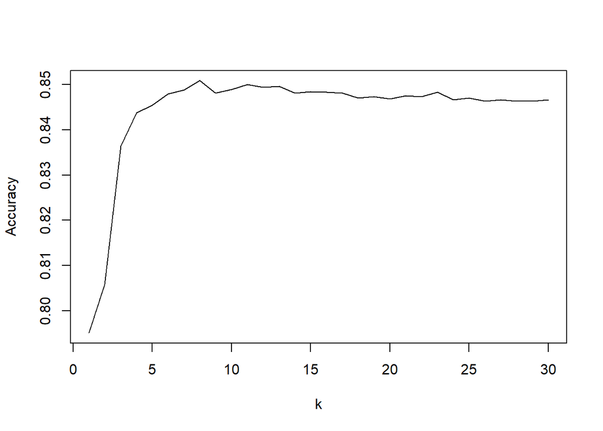

```r
x.train <- model.matrix(~ incident_brough + alarm_source_desc + alarm_level_idx +
    highest_alarm_lev + incident_resp_sec + incident_travel_time_sec +
    engines_assigned + ladders_assigned + other_utits_assigned +
    time_of_day, data = fire_data.train)[, -1]
x.test <- model.matrix(~ incident_brough + alarm_source_desc + alarm_level_idx +
    highest_alarm_lev + incident_resp_sec + incident_travel_time_sec +
    engines_assigned + ladders_assigned + other_utits_assigned +
    time_of_day, data = fire_data.test)[, -1]
library("class")
set.seed(98765)
rates <- double(30)
for (i in 1:30) {
  tmp <- knn(train = x.train, test = x.test, cl = fire_data.train$incident_class, k = i)
  rates[i] <- mean(tmp == fire_data.test$incident_class)
}
plot(x = (1:30), y = rates, xlab = "k", ylab = "Accuracy", type = "l")
```